# Collectively Classical - Manuscript Results

Dana Swarbrick

01/03/2023

# File description

This notebook accompanies the results presented in the Collectively Classical manuscript.

# Load Data

```r
df.full<-readRDS(file = "../output/Prepared_Data.Rda")

# rename ParticipantCode to Pt_ID because that is the name I began by using here.
names(df.full)[1]<-"Pt_ID"
```

Pt_ID has several codes that give different meaning.

- Position 1 Attendance condition: A: Participant attended concert in the hall in Copenhagen B: Participant attended concert via livestream
- Position 2 Questionnaire language condition: D: The participant answered questions in the Danish language version of the questionnaire E: The participant answered questions in the English language version of the questionnaire n: No questionnaire responses are available for this participant X: No questionnaire data by request
- Position 3 Motion quality condition: Q: Motion recorded via the MusicLab app and time series has been synced to concert time via at least one synchronization cue tap sequence. R: Motion recorded via AX3 sensor (hall only) and has been adjusted via either recorded synchronization tap sequence or estimated offset based on sensors initiated at the same time. S: Motion recorded via the MusicLab app but the time series has not been synced because there were no viable synchronization cues recorded in the series. T: Motion recorded via AX3 sensor but the time series has not been synced because there were no viable synchronization cues recorded in the series. U: No recorded motion is available for this participant V: Only a small amount of motion was recorded via MusicLab app, but it was during a sync cue. These files were excluded from publication but retained as records for tapping sync analysis.
- The participant numbers were assigned uniquely by sorting the participants according a sequence of criteria:
  0. All DeviceID, ascending (Fixed effectively random order)
  1. Questionnaire response completeness (descending)
  2. Motion quality condition
  3. Questionnaire language condition
  4. Attendance condition
  5. Exclusions

# Import Libraries

```r
packages = c("GPArotation","rmcorr", "cowplot", "ggpubr", "rstatix", "ltm","reshape2", "tidyverse", "psych", "nlme", "emmeans", "pastecs", "ordinal", "ggsignif", "ARTool", "multcomp", "easystats", "merDeriv", "ggeffects", "magrittr", "brms", "rstan", "StanHeaders", "lme4", "lmerTest")

## Now load or install&load all
package.check <- lapply(
  packages,
  FUN = function(x) {
    if (!require(x, character.only = TRUE)) {
      install.packages(x, dependencies = TRUE)
      library(x, character.only = TRUE)
    }
  }
)
```

[output not shown]

[output cut: 33 more lines]

[output not shown]

```r
source("useful_functions.R")
```

# 3.1 Participants

## Describe the sample

```r
#n
df.full%>%group_by(group)%>%count()
```

```
## # A tibble: 2 × 2
## # Groups:   group [2]
##   group       n
##   <fct>   <int>
## 1 Live       91
## 2 Virtual    45
```

```r
#gender
df.full%>%group_by(group,gender)%>%summarise(count = n())
```

```
## # A tibble: 6 × 3
## # Groups:   group [2]
##   group   gender                 count
##   <fct>   <fct>                  <int>
## 1 Live    Man                       37
## 2 Live    Woman                     53
## 3 Live    Choose Not to Identify     1
## 4 Virtual Man                       16
## 5 Virtual Woman                     19
## 6 Virtual <NA>                      10
```

```r
#age
df.full%>%group_by(group)%>%summarise(mean = mean(age, na.rm = TRUE), sd = sd(age, na.rm = TRUE))
```

```
## # A tibble: 2 × 3
##   group    mean    sd
##   <fct>   <dbl> <dbl>
## 1 Live     56.4  17.6
## 2 Virtual  43.8  15.6
```

```r
# language
df.full%>%group_by(group, language)%>%summarise(count = n())
```

```
## # A tibble: 4 × 3
## # Groups:   group [2]
##   group   language count
##   <fct>   <fct>    <int>
## 1 Live    Danish      76
## 2 Live    English     15
## 3 Virtual Danish       9
## 4 Virtual English     36
```

```r
#musician status
test<-df.full%>%group_by(group,musician_status)%>%summarise(count = n())
test2<-pivot_wider(test, names_from = group, values_from = count )
write.table(test2, file = "musician_status.txt", sep = ",", quote = FALSE, row.names = F)

# Personal Relation
df.full%>%group_by(group, personal_relation)%>%summarise(count = n())
```

```
## # A tibble: 5 × 3
## # Groups:   group [2]
##   group   personal_relation count
##   <fct>   <fct>             <int>
## 1 Live    No_Relation          74
## 2 Live    Relative_Friend      17
## 3 Virtual No_Relation          31
## 4 Virtual Relative_Friend       4
## 5 Virtual <NA>                 10
```

```r
# Fan-status
df.full%>%group_by(group)%>%summarise(mean = mean(fan, na.rm = TRUE), sd = sd(fan, na.rm = TRUE))
```

```
## # A tibble: 2 × 3
##   group    mean    sd
##   <fct>   <dbl> <dbl>
## 1 Live     5.58  2.12
## 2 Virtual  3.71  2.63
```

```r
# Empathic Concern
df.full%>%group_by(group)%>%summarise(mean = mean(EC, na.rm = TRUE), sd = sd(EC, na.rm = TRUE))
```

```
## # A tibble: 2 × 3
##   group    mean    sd
##   <fct>   <dbl> <dbl>
## 1 Live     3.84 0.653
## 2 Virtual  4.11 0.556
```

```r
# AIMS
df.full%>%select(Pt_ID, group, AIMS)%>%filter(!is.na(AIMS))%>%filter(group == "Virtual") # 14 participants: NA (All virtual); 31 participants in the virtual audience did respond on the aims scale.
```

```
## # A tibble: 31 × 3
##    Pt_ID  group    AIMS
##    <chr>  <fct>   <dbl>
##  1 BEQ099 Virtual    98
##  2 BEU125 Virtual   132
##  3 BEQ113 Virtual    89
##  4 BEU127 Virtual    85
##  5 BEQ109 Virtual   140
##  6 BEQ098 Virtual    98
##  7 BES122 Virtual    97
##  8 BES121 Virtual    95
##  9 BEQ101 Virtual    96
## 10 BEQ112 Virtual   114
## # … with 21 more rows
```

```r
df.full%>%summarise(mean = mean(AIMS, na.rm = TRUE),median = median(AIMS, na.rm = TRUE), sd = sd(AIMS, na.rm = TRUE), min = min(AIMS, na.rm = TRUE), max = max(AIMS, na.rm = TRUE)) # overall measure is very similar to that reported in Sandstrom and Russo (M = 113.5, SD = 23.8, Range = [46-164])
```

```
## # A tibble: 1 × 5
##    mean median    sd   min   max
##   <dbl>  <dbl> <dbl> <dbl> <dbl>
## 1  114.    117  25.0    50   164
```

```r
df.full%>%group_by(group)%>%summarise(mean = mean(AIMS, na.rm = TRUE),median = median(AIMS,  na.rm = TRUE), sd = sd(AIMS, na.rm = TRUE))
```

```
## # A tibble: 2 × 4
##   group    mean median    sd
##   <fct>   <dbl>  <dbl> <dbl>
## 1 Live     112.    113  26.2
## 2 Virtual  121.    125  19.8
```

```r
# How much movement data was there?
df.full%>%select(Pt_ID, group, contains("mQoM"))%>%pivot_longer(!c(Pt_ID,group),
                        names_to = "piece",
                        names_pattern ="_(.*)",
                        values_to = "mQoM")%>%drop_na%>%group_by(group, piece)%>%summarise(count = n())
```

```
## # A tibble: 8 × 3
## # Groups:   group [2]
##   group   piece     count
##   <fct>   <chr>     <int>
## 1 Live    Bach         78
## 2 Live    Beethoven    82
## 3 Live    Folk         78
## 4 Live    Schnittke    78
## 5 Virtual Bach         21
## 6 Virtual Beethoven    25
## 7 Virtual Folk         22
## 8 Virtual Schnittke    23
```

```r
### Group size
#How many people were in each group?

df.full%>%group_by(group, group_size)%>%summarise(count = n())
```

```
## # A tibble: 9 × 3
## # Groups:   group [2]
##   group   group_size count
##   <fct>        <dbl> <int>
## 1 Live             1    13
## 2 Live             2    30
## 3 Live             3    27
## 4 Live             4    10
## 5 Live             5     6
## 6 Live             6     3
## 7 Live             7     1
## 8 Live             8     1
## 9 Virtual         NA    45
```

```r
df.full%>%group_by(group)%>%summarise(mean = mean(group_size, na.rm = TRUE),
                                      SD = SD(group_size, na.rm = TRUE))
```

```
## # A tibble: 2 × 3
##   group     mean    SD
##   <fct>    <dbl> <dbl>
## 1 Live      2.82  1.42
## 2 Virtual NaN    NA
```

## Check for differences between groups (age and musician status?)

### Age: Two-sample t-test

```r
t.test(df.full$age~df.full$group)
```

```
##
##  Welch Two Sample t-test
##
## data:  df.full$age by df.full$group
## t = 3.7255, df = 75.537, p-value = 0.0003738
## alternative hypothesis: true difference in means between group Live and group Virtual is not equal to 0
## 95 percent confidence interval:
##   5.834248 19.241003
## sample estimates:
##    mean in group Live mean in group Virtual
##              56.36620              43.82857
```

### Musician status (ordinal) Kruskal Wallis test

The Kruskal Wallis test is used when you have one independent variable with two or more levels and an ordinal dependent variable.

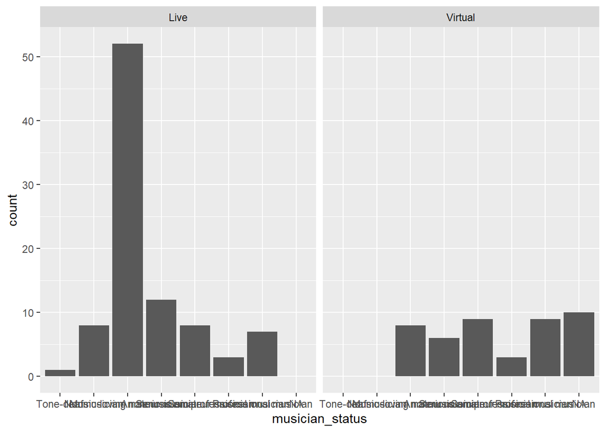

```r
ggplot(df.full, aes(x = musician_status))+geom_bar()+facet_grid(cols = vars(group)) # these distributions don't really look the same :/
```

```r
kruskal.test(musician_status~group, data = df.full)
```

```
##
##  Kruskal-Wallis rank sum test
##
## data:  musician_status by group
## Kruskal-Wallis chi-squared = 22.421, df = 1, p-value = 2.19e-06
```

### Language (Chi-square)

Were there more Danish in the live audience than the livestreaming and more English in the livestream?

```r
table(df.full$group, df.full$language)
```

```
##
##           Danish English
##   Live        76      15
##   Virtual      9      36
```

```r
chisq.test(df.full$group, df.full$language)
```

```
##
##  Pearson's Chi-squared test with Yates' continuity correction
##
## data:  df.full$group and df.full$language
## X-squared = 49.155, df = 1, p-value = 2.365e-12
```

### Watching alone (Chi-square)

How many people were watching alone per group?

```r
df.full%>%group_by(group, Watch_Alone)%>%summarise(count = n())
```

```
## # A tibble: 5 × 3
## # Groups:   group [2]
##   group   Watch_Alone count
##   <fct>         <dbl> <int>
## 1 Live              0    84
## 2 Live              1     7
## 3 Virtual           0    11
## 4 Virtual           1    28
## 5 Virtual          NA     6
```

```r
chisq.test(df.full$group, df.full$Watch_Alone)
```

```
##
##  Pearson's Chi-squared test with Yates' continuity correction
##
## data:  df.full$group and df.full$Watch_Alone
## X-squared = 53.806, df = 1, p-value = 2.213e-13
```

### Fan-status (ordinal) Kruskal Wallis test

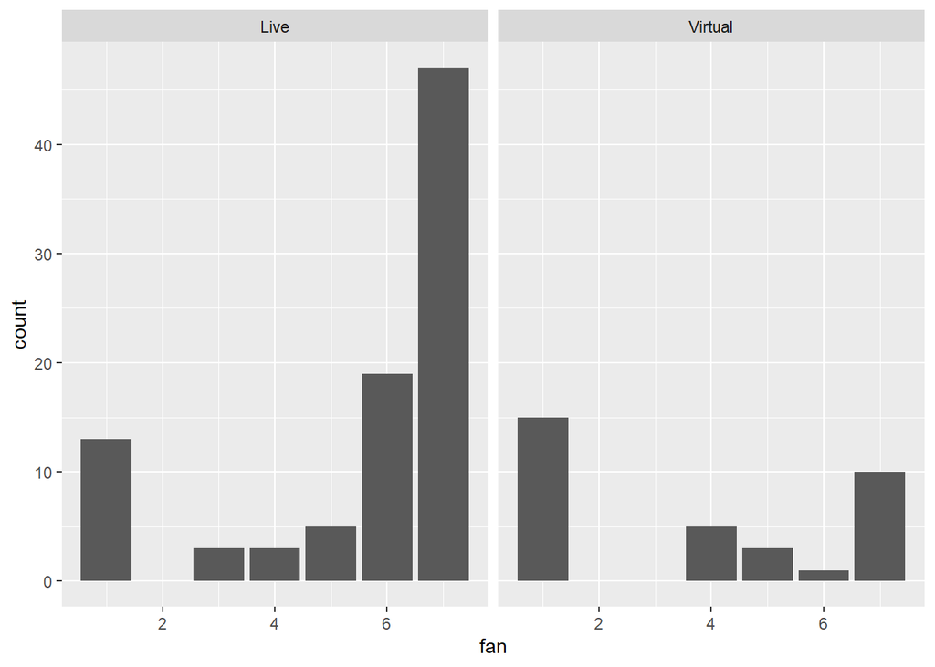

```r
ggplot(df.full, aes(x = fan))+geom_bar()+facet_grid(cols = vars(group)) # these distributions don't look the same therefore conduct non-parametric test
```

```r
kruskal.test(fan~group, data = df.full)
```

```
##
##  Kruskal-Wallis rank sum test
##
## data:  fan by group
## Kruskal-Wallis chi-squared = 11.985, df = 1, p-value = 0.0005363
```

### AIMS

```r
AIMS_dat<-df.full%>%select(group,contains("AIMS"))
#could also test with syntax:
t.test(df.full$AIMS~df.full$group)
```

```
##
##  Welch Two Sample t-test
##
## data:  df.full$AIMS by df.full$group
## t = -1.9947, df = 68.42, p-value = 0.05006
## alternative hypothesis: true difference in means between group Live and group Virtual is not equal to 0
## 95 percent confidence interval:
##  -17.917515047   0.002591261
## sample estimates:
##    mean in group Live mean in group Virtual
##              111.9780              120.9355
```

### Empathic concern

```r
EC_dat<-df.full%>%select(group,contains("EC"))%>%select(-contains("connected"),-contains("aware"))
t.test(df.full$EC~df.full$group)
```

```
##
##  Welch Two Sample t-test
##
## data:  df.full$EC by df.full$group
## t = -2.2949, df = 72.015, p-value = 0.02465
## alternative hypothesis: true difference in means between group Live and group Virtual is not equal to 0
## 95 percent confidence interval:
##  -0.4984989 -0.0350437
## sample estimates:
##    mean in group Live mean in group Virtual
##              3.839351              4.106122
```

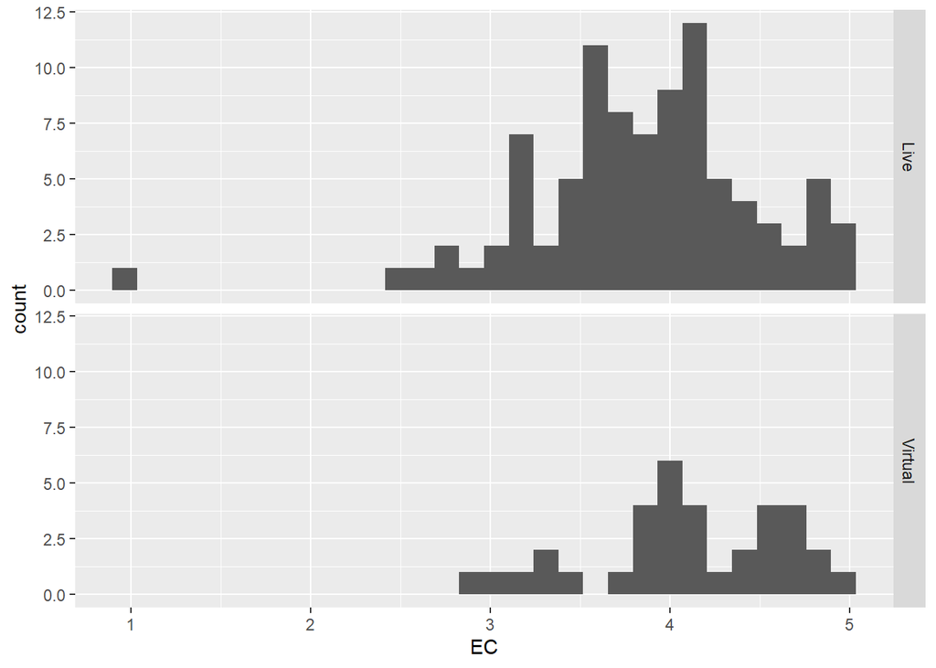

```r
# the t-test assumes a normal distribution and equal variances from both groups. Is that assumption met for this data?
EC_dat%>%
  ggplot(aes(EC))+
  geom_histogram()+
  facet_grid(vars(group))
```

```r
# maybe it is not satisfying assumptions?
live_EC<-df.full%>%filter(group == "Live")%>%select(EC)%>%na.omit()
virtual_EC<-df.full%>%filter(group == "Virtual")%>%select(EC)%>%na.omit()

# still significant with non-parametric version
wilcox.test(live_EC$EC, virtual_EC$EC, alternative = "two.sided")
```

```
##
##  Wilcoxon rank sum test with continuity correction
##
## data:  live_EC$EC and virtual_EC$EC
## W = 1200, p-value = 0.03222
## alternative hypothesis: true location shift is not equal to 0
```

### Countries (Virtual)

How many countries did the livestreaming audience view from?

The livestreaming audience consisted of participants from 16 countries mostly from Europe (Denmark: n = 5, Norway: n = 5, Russia: n = 3, Sweden: n = 2, Austria: n = 2, Germany: n = 2, Romania: n = 2, France: n = 1, Hungary: n = 1, Netherlands: n = 1, Portugal, n = 1, Switzerland: n = 1, UK: n = 1) and the Americas (USA: n = 5, Canada: n = 2, Ecuador: n = 1).

```r
country_Count<-df.full%>%filter(group == "Virtual")%>%group_by(country)%>%summarise(n())

country_Count
```

```
## # A tibble: 17 × 2
##    country     `n()`
##    <chr>       <int>
##  1 Austria         2
##  2 Canada          2
##  3 Denmark         5
##  4 Ecuador         1
##  5 France          1
##  6 Germany         2
##  7 Hungary         1
##  8 Netherlands     1
##  9 Norway          5
## 10 Portugal        1
## 11 Romania         2
## 12 Russia          3
## 13 Sweden          2
## 14 Switzerland     1
## 15 UK              1
## 16 USA             5
## 17 <NA>           10
```

# 3.2 Scale Reliability

Check internal reliability with omega.

## Kama Muta

The kama muta scale demonstrated good reliability with high omega values for each piece (Beethoven: .92, Schnittke: .90, Folk: .92, overall: .91).

```r
df_KM<-df.full%>%
  select(Pt_ID, tears_Beethoven:positive_Beethoven, moved_Beethoven:touched_Beethoven, KM_Beethoven, tears_Schnittke:positive_Schnittke, moved_Schnittke:touched_Schnittke,
         KM_Schnittke, tears_Folk:positive_Folk, moved_Folk:touched_Folk, KM_Folk)

df_KM.long<-df_KM%>%pivot_longer(!Pt_ID,
                        names_to = c("question", "piece"),
                        names_pattern ="(.*)_(.*)",
                        values_to = "response")

df_KM.wide<-df_KM.long%>%pivot_wider(names_from = question, values_from = response)
```

```r
df_kamamuta<-df_KM.wide%>%select(-Pt_ID, -piece)
lowerCor(df_kamamuta)
```

```
##              tears chlls wrm_f chkd_ rfrsh wlcmn clsns postv moved tochd KM
## tears        1.00
## chills       0.47  1.00
## warm_feeling 0.42  0.33  1.00
## choked_up    0.60  0.43  0.37  1.00
## refreshed    0.24  0.27  0.41  0.22  1.00
## welcoming    0.33  0.32  0.57  0.28  0.54  1.00
## closeness    0.34  0.35  0.58  0.27  0.51  0.75  1.00
## positive     0.25  0.24  0.36  0.21  0.68  0.55  0.49  1.00
## moved        0.38  0.39  0.40  0.35  0.47  0.44  0.47  0.51  1.00
## touched      0.42  0.40  0.37  0.40  0.42  0.41  0.40  0.43  0.72  1.00
## KM           0.63  0.61  0.71  0.58  0.69  0.76  0.76  0.67  0.74  0.73  1.00
```

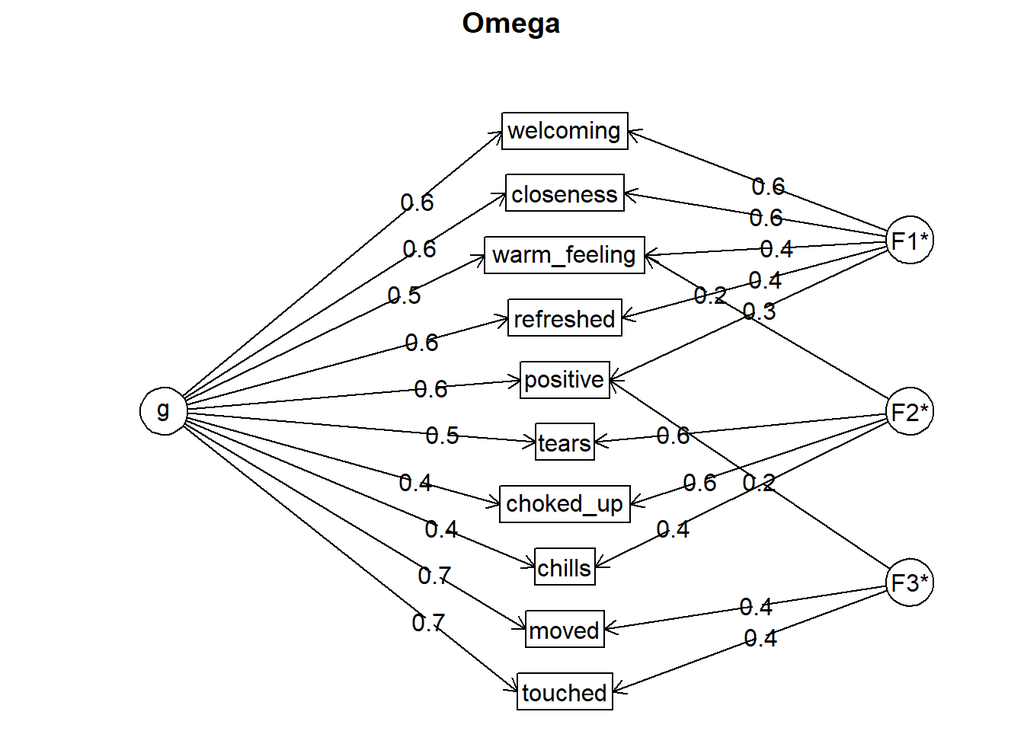

```
## Omega
## Call: omegah(m = m, nfactors = nfactors, fm = fm, key = key, flip = flip,
##     digits = digits, title = title, sl = sl, labels = labels,
##     plot = plot, n.obs = n.obs, rotate = rotate, Phi = Phi, option = option,
##     covar = covar)
## Alpha:                 0.88
## G.6:                   0.9
## Omega Hierarchical:    0.67
## Omega H asymptotic:    0.74
## Omega Total            0.91
##
## Schmid Leiman Factor loadings greater than  0.2
##                 g   F1*   F2*   F3*   h2   u2   p2
## tears        0.47        0.63       0.63 0.37 0.35
## chills       0.44        0.39       0.36 0.64 0.54
## warm_feeling 0.50  0.43  0.25       0.49 0.51 0.50
## choked_up    0.43        0.59       0.53 0.47 0.34
## refreshed    0.60  0.36        0.20 0.55 0.45 0.66
## welcoming    0.59  0.64             0.76 0.24 0.46
## closeness    0.58  0.59             0.69 0.31 0.49
## positive     0.61  0.32        0.23 0.57 0.43 0.66
## moved        0.74              0.40 0.71 0.29 0.76
## touched      0.69              0.38 0.65 0.35 0.74
##
## With Sums of squares  of:
##    g  F1*  F2*  F3*
## 3.30 1.18 1.04 0.41
##
## general/max  2.8   max/min =   2.86
## mean percent general =  0.55    with sd =  0.15 and cv of  0.27
## Explained Common Variance of the general factor =  0.56
##
## The degrees of freedom are 18  and the fit is  0.25
## The number of observations was  408  with Chi Square =  99.53  with prob <  2.7e-13
## The root mean square of the residuals is  0.03
## The df corrected root mean square of the residuals is  0.05
## RMSEA index =  0.105  and the 10 % confidence intervals are  0.086 0.126
## BIC =  -8.68
##
## Compare this with the adequacy of just a general factor and no group factors
## The degrees of freedom for just the general factor are 35  and the fit is  1.51
## The number of observations was  408  with Chi Square =  608.55  with prob <  8.3e-106
## The root mean square of the residuals is  0.15
## The df corrected root mean square of the residuals is  0.17
##
## RMSEA index =  0.2  and the 10 % confidence intervals are  0.187 0.215
## BIC =  398.16
##
## Measures of factor score adequacy
##                                                  g  F1*  F2*   F3*
## Correlation of scores with factors            0.85 0.78 0.80  0.53
## Multiple R square of scores with factors      0.73 0.61 0.65  0.28
## Minimum correlation of factor score estimates 0.45 0.22 0.29 -0.44
##
##  Total, General and Subset omega for each subset
##                                                  g  F1*  F2*  F3*
## Omega total for total scores and subscales    0.91 0.87 0.73 0.77
## Omega general for total scores and subscales  0.67 0.52 0.30 0.59
## Omega group for total scores and subscales    0.18 0.34 0.43 0.18
```

```r
df_kamamuta_items<-df_kamamuta%>%select(-KM) #remove the avg of the items.
omega(df_kamamuta_items)
```

### Piece-wise

Beethoven: .92, Schnittke: .90, Folk: .92

```r
# Beethoven
KM_Beethoven<-df.full%>%
  select(tears_Beethoven:positive_Beethoven, moved_Beethoven:touched_Beethoven)

print(summary(psych::alpha(KM_Beethoven))$raw_alpha)
```

```
##
## Reliability analysis
##  raw_alpha std.alpha G6(smc) average_r S/N   ase mean  sd median_r
##       0.89      0.89    0.91      0.44 7.9 0.014  2.8 1.2     0.43
## NULL
```

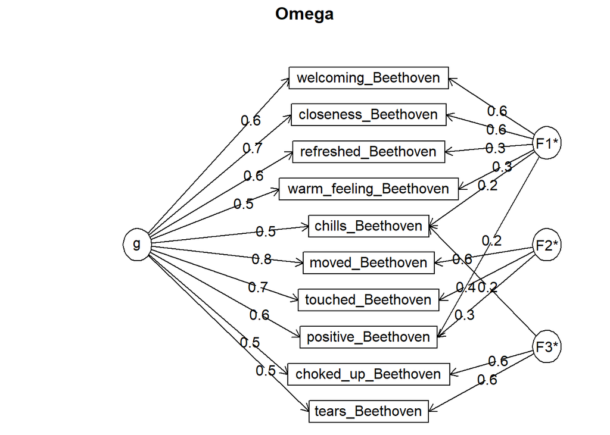

```
## Omega
## Call: omegah(m = m, nfactors = nfactors, fm = fm, key = key, flip = flip,
##     digits = digits, title = title, sl = sl, labels = labels,
##     plot = plot, n.obs = n.obs, rotate = rotate, Phi = Phi, option = option,
##     covar = covar)
## Alpha:                 0.89
## G.6:                   0.91
## Omega Hierarchical:    0.71
## Omega H asymptotic:    0.77
## Omega Total            0.92
##
## Schmid Leiman Factor loadings greater than  0.2
##                           g   F1*   F2*   F3*   h2   u2   p2
## tears_Beethoven        0.51              0.63 0.67 0.33 0.40
## chills_Beethoven       0.52  0.25        0.23 0.39 0.61 0.70
## warm_feeling_Beethoven 0.51  0.34             0.41 0.59 0.64
## choked_up_Beethoven    0.50              0.65 0.67 0.33 0.37
## refreshed_Beethoven    0.58  0.34             0.49 0.51 0.70
## welcoming_Beethoven    0.63  0.58             0.73 0.27 0.54
## closeness_Beethoven    0.66  0.57             0.77 0.23 0.58
## positive_Beethoven     0.56  0.23  0.29       0.46 0.54 0.67
## moved_Beethoven        0.77        0.55       0.90 0.10 0.66
## touched_Beethoven      0.69        0.41       0.66 0.34 0.72
##
## With Sums of squares  of:
##    g  F1*  F2*  F3*
## 3.60 1.01 0.59 0.96
##
## general/max  3.58   max/min =   1.72
## mean percent general =  0.6    with sd =  0.13 and cv of  0.21
## Explained Common Variance of the general factor =  0.59
##
## The degrees of freedom are 18  and the fit is  0.24
## The number of observations was  136  with Chi Square =  31.29  with prob <  0.027
## The root mean square of the residuals is  0.03
## The df corrected root mean square of the residuals is  0.05
## RMSEA index =  0.073  and the 10 % confidence intervals are  0.025 0.116
## BIC =  -57.14
##
## Compare this with the adequacy of just a general factor and no group factors
## The degrees of freedom for just the general factor are 35  and the fit is  1.57
## The number of observations was  136  with Chi Square =  203.92  with prob <  1e-25
## The root mean square of the residuals is  0.14
## The df corrected root mean square of the residuals is  0.15
##
## RMSEA index =  0.188  and the 10 % confidence intervals are  0.164 0.215
## BIC =  31.98
##
## Measures of factor score adequacy
##                                                  g  F1*   F2*  F3*
## Correlation of scores with factors            0.87 0.75  0.69 0.81
## Multiple R square of scores with factors      0.75 0.57  0.47 0.66
## Minimum correlation of factor score estimates 0.50 0.14 -0.06 0.31
##
##  Total, General and Subset omega for each subset
##                                                  g  F1*  F2*  F3*
## Omega total for total scores and subscales    0.92 0.84 0.85 0.79
## Omega general for total scores and subscales  0.71 0.56 0.62 0.30
## Omega group for total scores and subscales    0.15 0.28 0.24 0.49
```

```r
omega(KM_Beethoven)
```

```r
# Schnittke
KM_Schnittke<-df.full%>%
  select(tears_Schnittke:positive_Schnittke, moved_Schnittke:touched_Schnittke)

print(summary(psych::alpha(KM_Schnittke))$raw_alpha)
```

```
##
## Reliability analysis
##  raw_alpha std.alpha G6(smc) average_r S/N   ase mean  sd median_r
##       0.86      0.86    0.89      0.38 6.1 0.018  2.5 1.1     0.35
## NULL
```

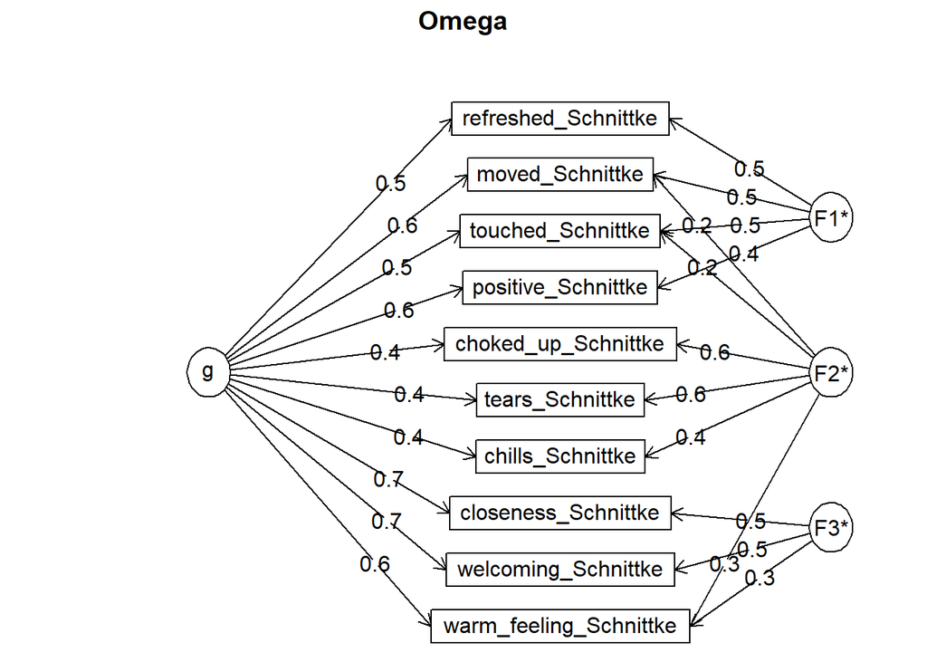

```
## Omega
## Call: omegah(m = m, nfactors = nfactors, fm = fm, key = key, flip = flip,
##     digits = digits, title = title, sl = sl, labels = labels,
##     plot = plot, n.obs = n.obs, rotate = rotate, Phi = Phi, option = option,
##     covar = covar)
## Alpha:                 0.86
## G.6:                   0.89
## Omega Hierarchical:    0.64
## Omega H asymptotic:    0.71
## Omega Total            0.9
##
## Schmid Leiman Factor loadings greater than  0.2
##                           g   F1*   F2*   F3*   h2   u2   p2
## tears_Schnittke        0.43        0.62       0.57 0.43 0.32
## chills_Schnittke       0.39        0.35       0.30 0.70 0.52
## warm_feeling_Schnittke 0.57        0.27  0.32 0.49 0.51 0.65
## choked_up_Schnittke    0.41        0.65       0.59 0.41 0.28
## refreshed_Schnittke    0.54  0.49             0.57 0.43 0.52
## welcoming_Schnittke    0.65              0.48 0.66 0.34 0.64
## closeness_Schnittke    0.68              0.55 0.78 0.22 0.60
## positive_Schnittke     0.59  0.42             0.56 0.44 0.61
## moved_Schnittke        0.55  0.45  0.20       0.55 0.45 0.56
## touched_Schnittke      0.48  0.45  0.24       0.50 0.50 0.46
##
## With Sums of squares  of:
##    g  F1*  F2*  F3*
## 2.89 0.86 1.13 0.69
##
## general/max  2.55   max/min =   1.63
## mean percent general =  0.52    with sd =  0.13 and cv of  0.25
## Explained Common Variance of the general factor =  0.52
##
## The degrees of freedom are 18  and the fit is  0.43
## The number of observations was  136  with Chi Square =  55.43  with prob <  1.1e-05
## The root mean square of the residuals is  0.04
## The df corrected root mean square of the residuals is  0.07
## RMSEA index =  0.123  and the 10 % confidence intervals are  0.088 0.162
## BIC =  -33
##
## Compare this with the adequacy of just a general factor and no group factors
## The degrees of freedom for just the general factor are 35  and the fit is  1.52
## The number of observations was  136  with Chi Square =  197.6  with prob <  1.4e-24
## The root mean square of the residuals is  0.15
## The df corrected root mean square of the residuals is  0.17
##
## RMSEA index =  0.185  and the 10 % confidence intervals are  0.161 0.211
## BIC =  25.66
##
## Measures of factor score adequacy
##                                                  g   F1*  F2*   F3*
## Correlation of scores with factors            0.82  0.69 0.81  0.66
## Multiple R square of scores with factors      0.67  0.48 0.65  0.43
## Minimum correlation of factor score estimates 0.34 -0.03 0.30 -0.13
##
##  Total, General and Subset omega for each subset
##                                                  g  F1*  F2*  F3*
## Omega total for total scores and subscales    0.90 0.81 0.71 0.82
## Omega general for total scores and subscales  0.64 0.47 0.26 0.54
## Omega group for total scores and subscales    0.18 0.34 0.45 0.27
```

```r
omega(KM_Schnittke)
```

```r
# Folk
KM_Folk<-df.full%>%
  select(tears_Folk:positive_Folk, moved_Folk:touched_Folk)

print(summary(psych::alpha(KM_Folk))$raw_alpha)
```

```
##
## Reliability analysis
##  raw_alpha std.alpha G6(smc) average_r S/N   ase mean  sd median_r
##       0.88      0.88    0.91      0.43 7.5 0.015  3.2 1.2     0.43
## NULL
```

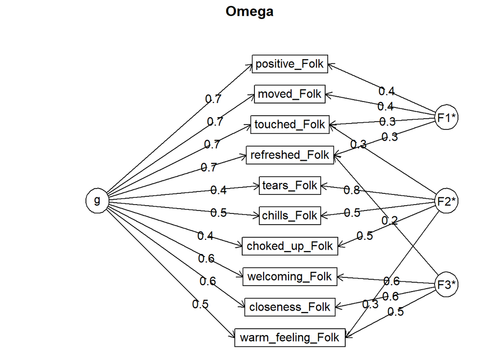

```
## Omega
## Call: omegah(m = m, nfactors = nfactors, fm = fm, key = key, flip = flip,
##     digits = digits, title = title, sl = sl, labels = labels,
##     plot = plot, n.obs = n.obs, rotate = rotate, Phi = Phi, option = option,
##     covar = covar)
## Alpha:                 0.88
## G.6:                   0.91
## Omega Hierarchical:    0.68
## Omega H asymptotic:    0.73
## Omega Total            0.92
##
## Schmid Leiman Factor loadings greater than  0.2
##                      g   F1*   F2*   F3*   h2   u2   p2
## tears_Folk        0.41        0.76       0.76 0.24 0.23
## chills_Folk       0.51        0.51       0.54 0.46 0.48
## warm_feeling_Folk 0.47        0.29  0.46 0.52 0.48 0.43
## choked_up_Folk    0.37        0.51       0.40 0.60 0.34
## refreshed_Folk    0.65  0.29        0.22 0.56 0.44 0.75
## welcoming_Folk    0.64              0.59 0.77 0.23 0.54
## closeness_Folk    0.64              0.59 0.76 0.24 0.54
## positive_Folk     0.69  0.41             0.68 0.32 0.71
## moved_Folk        0.69  0.40             0.66 0.34 0.72
## touched_Folk      0.66  0.35  0.28       0.64 0.36 0.69
##
## With Sums of squares  of:
##    g  F1*  F2*  F3*
## 3.43 0.57 1.32 0.98
##
## general/max  2.61   max/min =   2.32
## mean percent general =  0.54    with sd =  0.18 and cv of  0.32
## Explained Common Variance of the general factor =  0.55
##
## The degrees of freedom are 18  and the fit is  0.22
## The number of observations was  136  with Chi Square =  27.96  with prob <  0.063
## The root mean square of the residuals is  0.03
## The df corrected root mean square of the residuals is  0.04
## RMSEA index =  0.063  and the 10 % confidence intervals are  0 0.108
## BIC =  -60.47
##
## Compare this with the adequacy of just a general factor and no group factors
## The degrees of freedom for just the general factor are 35  and the fit is  1.75
## The number of observations was  136  with Chi Square =  227.4  with prob <  4.7e-30
## The root mean square of the residuals is  0.16
## The df corrected root mean square of the residuals is  0.18
##
## RMSEA index =  0.201  and the 10 % confidence intervals are  0.177 0.227
## BIC =  55.46
##
## Measures of factor score adequacy
##                                                  g   F1*  F2*  F3*
## Correlation of scores with factors            0.85  0.57 0.86 0.77
## Multiple R square of scores with factors      0.72  0.33 0.74 0.59
## Minimum correlation of factor score estimates 0.45 -0.35 0.48 0.18
##
##  Total, General and Subset omega for each subset
##                                                  g  F1*  F2*  F3*
## Omega total for total scores and subscales    0.92 0.86 0.78 0.85
## Omega general for total scores and subscales  0.68 0.66 0.27 0.45
## Omega group for total scores and subscales    0.16 0.19 0.51 0.40
```

```r
omega(KM_Folk)
```

## Awe

```r
awe_items<-c("presence_grand", "greater_than_myself", "jaw_drop", "gasped", "challenge_process", "hard_comprehend")

df_awe<-df.full%>%select(Pt_ID, contains(awe_items))

df_awe.long<-df_awe%>%pivot_longer(!Pt_ID,
                        names_to = c("question", "piece"),
                        names_pattern ="(.*)_(.*)",
                        values_to = "response")

df_awe.wide<-df_awe.long%>%pivot_wider(names_from = question, values_from = response)
```

But this is maybe not accurate because it makes sense it would be higher when here are repeated measures. Therefore, check the piece-wise values.

```r
df_Aw<-df_awe.wide%>%select(-Pt_ID, -piece)
lowerCor(df_Aw)
```

```
##                     prsn_ grt__ jw_dr gaspd chll_ hrd_c
## presence_grand      1.00
## greater_than_myself 0.73  1.00
## jaw_drop            0.35  0.32  1.00
## gasped              0.31  0.25  0.56  1.00
## challenge_process   0.27  0.22  0.19  0.15  1.00
## hard_comprehend     0.27  0.26  0.17  0.19  0.48  1.00
```

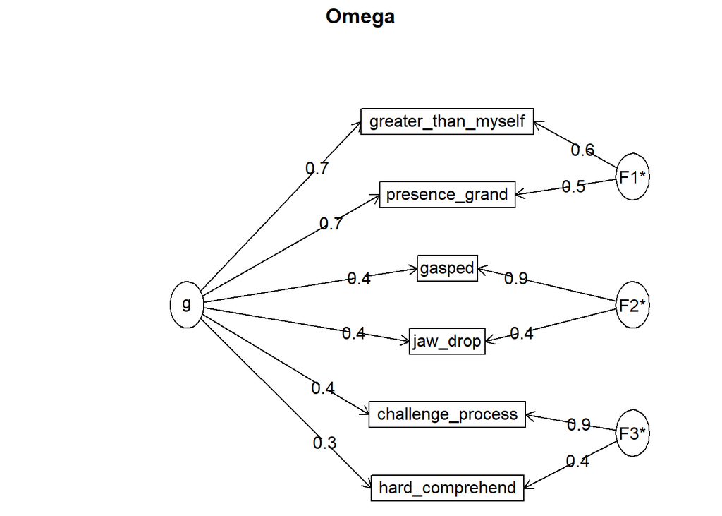

```
## Omega
## Call: omegah(m = m, nfactors = nfactors, fm = fm, key = key, flip = flip,
##     digits = digits, title = title, sl = sl, labels = labels,
##     plot = plot, n.obs = n.obs, rotate = rotate, Phi = Phi, option = option,
##     covar = covar)
## Alpha:                 0.73
## G.6:                   0.76
## Omega Hierarchical:    0.52
## Omega H asymptotic:    0.59
## Omega Total            0.88
##
## Schmid Leiman Factor loadings greater than  0.2
##                        g   F1*   F2*   F3*   h2   u2   p2
## presence_grand      0.66  0.52             0.71 0.29 0.61
## greater_than_myself 0.66  0.57             0.77 0.23 0.57
## jaw_drop            0.39        0.44       0.37 0.63 0.43
## gasped              0.43        0.90       1.00 0.00 0.19
## challenge_process   0.37              0.92 1.00 0.00 0.14
## hard_comprehend     0.32              0.39 0.27 0.73 0.37
##
## With Sums of squares  of:
##    g  F1*  F2*  F3*
## 1.46 0.63 1.01 1.01
##
## general/max  1.44   max/min =   1.62
## mean percent general =  0.38    with sd =  0.19 and cv of  0.5
## Explained Common Variance of the general factor =  0.36
##
## The degrees of freedom are 0  and the fit is  0
## The number of observations was  408  with Chi Square =  0.51  with prob <  NA
## The root mean square of the residuals is  0
## The df corrected root mean square of the residuals is  NA
##
## Compare this with the adequacy of just a general factor and no group factors
## The degrees of freedom for just the general factor are 9  and the fit is  0.67
## The number of observations was  408  with Chi Square =  269.72  with prob <  6.8e-53
## The root mean square of the residuals is  0.16
## The df corrected root mean square of the residuals is  0.21
##
## RMSEA index =  0.266  and the 10 % confidence intervals are  0.24 0.295
## BIC =  215.62
##
## Measures of factor score adequacy
##                                                  g   F1*  F2*  F3*
## Correlation of scores with factors            0.77  0.64 0.95 0.96
## Multiple R square of scores with factors      0.59  0.41 0.89 0.92
## Minimum correlation of factor score estimates 0.18 -0.18 0.79 0.85
##
##  Total, General and Subset omega for each subset
##                                                  g  F1*  F2*  F3*
## Omega total for total scores and subscales    0.88 0.85 0.79 0.75
## Omega general for total scores and subscales  0.52 0.50 0.22 0.16
## Omega group for total scores and subscales    0.30 0.34 0.57 0.59
```

```r
omega(df_Aw)
```

###Piece-wise

```r
#Beethoven
AWE_B<-df.full%>%
  select(Pt_ID, contains("Beethoven"))%>%
  select(Pt_ID, contains(c("presence_grand", "greater_than_myself", "jaw_drop", "gasped", "challenge_process", "hard_comprehend")))
AWE<-AWE_B%>%select(-Pt_ID)

print(summary(psych::alpha(AWE))$raw_alpha)
```

```
##
## Reliability analysis
##  raw_alpha std.alpha G6(smc) average_r S/N   ase mean  sd median_r
##       0.66      0.67     0.7      0.25   2 0.046  3.9 1.1     0.23
## NULL
```

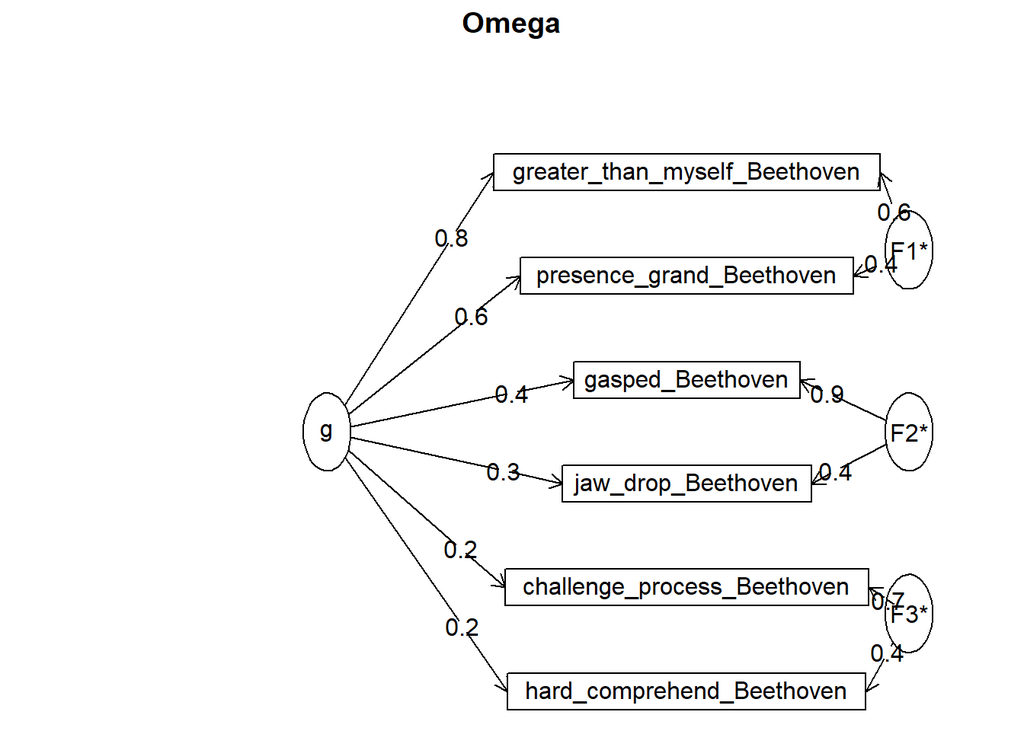

```
## Omega
## Call: omegah(m = m, nfactors = nfactors, fm = fm, key = key, flip = flip,
##     digits = digits, title = title, sl = sl, labels = labels,
##     plot = plot, n.obs = n.obs, rotate = rotate, Phi = Phi, option = option,
##     covar = covar)
## Alpha:                 0.67
## G.6:                   0.7
## Omega Hierarchical:    0.49
## Omega H asymptotic:    0.59
## Omega Total            0.82
##
## Schmid Leiman Factor loadings greater than  0.2
##                                  g   F1*   F2*   F3*   h2   u2   p2
## presence_grand_Beethoven      0.63  0.38             0.56 0.44 0.70
## greater_than_myself_Beethoven 0.80  0.56             0.97 0.03 0.67
## jaw_drop_Beethoven            0.28        0.42       0.27 0.73 0.30
## gasped_Beethoven              0.38        0.92       1.00 0.00 0.14
## challenge_process_Beethoven   0.25              0.71 0.56 0.44 0.11
## hard_comprehend_Beethoven     0.24              0.41 0.23 0.77 0.24
##
## With Sums of squares  of:
##    g  F1*  F2*  F3*
## 1.38 0.47 1.04 0.69
##
## general/max  1.33   max/min =   2.23
## mean percent general =  0.36    with sd =  0.26 and cv of  0.72
## Explained Common Variance of the general factor =  0.39
##
## The degrees of freedom are 0  and the fit is  0
## The number of observations was  136  with Chi Square =  0.16  with prob <  NA
## The root mean square of the residuals is  0.01
## The df corrected root mean square of the residuals is  NA
##
## Compare this with the adequacy of just a general factor and no group factors
## The degrees of freedom for just the general factor are 9  and the fit is  0.46
## The number of observations was  136  with Chi Square =  60.71  with prob <  9.8e-10
## The root mean square of the residuals is  0.14
## The df corrected root mean square of the residuals is  0.18
##
## RMSEA index =  0.205  and the 10 % confidence intervals are  0.159 0.257
## BIC =  16.5
##
## Measures of factor score adequacy
##                                                  g   F1*  F2*  F3*
## Correlation of scores with factors            0.83  0.60 0.97 0.76
## Multiple R square of scores with factors      0.68  0.36 0.94 0.58
## Minimum correlation of factor score estimates 0.37 -0.28 0.88 0.15
##
##  Total, General and Subset omega for each subset
##                                                  g  F1*  F2*  F3*
## Omega total for total scores and subscales    0.82 0.86 0.75 0.55
## Omega general for total scores and subscales  0.49 0.60 0.15 0.09
## Omega group for total scores and subscales    0.29 0.26 0.61 0.46
```

```r
omega(AWE)
```

```r
#Schnittke
AWE_S<-df.full%>%
  select(Pt_ID, contains("Schnittke"))%>%
  select(Pt_ID, contains(c("presence_grand", "greater_than_myself", "jaw_drop", "gasped", "challenge_process", "hard_comprehend")))
AWE<-AWE_S%>%select(-Pt_ID)

print(summary(psych::alpha(AWE))$raw_alpha)
```

```
##
## Reliability analysis
##  raw_alpha std.alpha G6(smc) average_r S/N   ase mean  sd median_r
##       0.72      0.72    0.76       0.3 2.6 0.038  4.1 1.2     0.25
## NULL
```

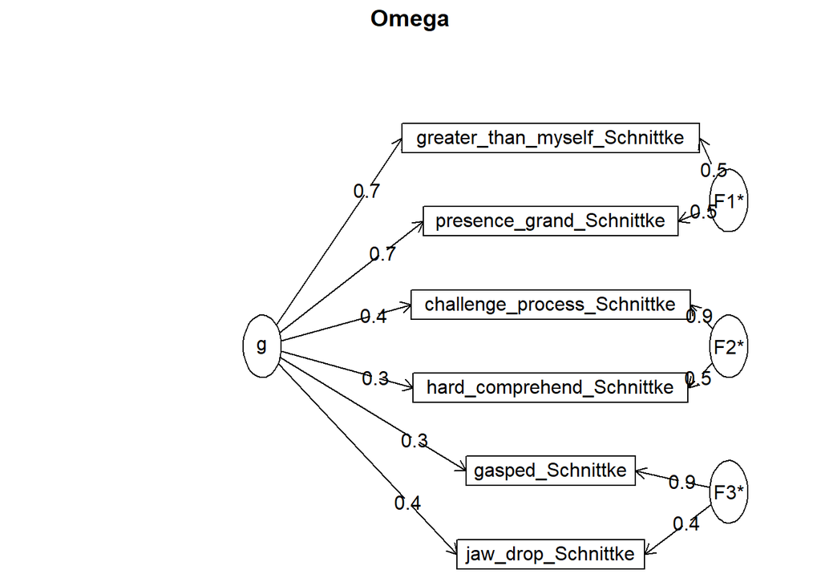

```
## Omega
## Call: omegah(m = m, nfactors = nfactors, fm = fm, key = key, flip = flip,
##     digits = digits, title = title, sl = sl, labels = labels,
##     plot = plot, n.obs = n.obs, rotate = rotate, Phi = Phi, option = option,
##     covar = covar)
## Alpha:                 0.72
## G.6:                   0.76
## Omega Hierarchical:    0.51
## Omega H asymptotic:    0.58
## Omega Total            0.88
##
## Schmid Leiman Factor loadings greater than  0.2
##                                  g   F1*   F2*   F3*   h2   u2   p2
## presence_grand_Schnittke      0.71  0.46             0.73 0.27 0.70
## greater_than_myself_Schnittke 0.71  0.50             0.76 0.24 0.66
## jaw_drop_Schnittke            0.42              0.36 0.35 0.65 0.51
## gasped_Schnittke              0.31              0.95 1.00 0.00 0.10
## challenge_process_Schnittke   0.36        0.93       1.00 0.00 0.13
## hard_comprehend_Schnittke     0.25        0.48       0.30 0.70 0.21
##
## With Sums of squares  of:
##   g F1* F2* F3*
## 1.5 0.5 1.1 1.0
##
## general/max  1.32   max/min =   2.24
## mean percent general =  0.38    with sd =  0.27 and cv of  0.7
## Explained Common Variance of the general factor =  0.36
##
## The degrees of freedom are 0  and the fit is  0
## The number of observations was  136  with Chi Square =  0.18  with prob <  NA
## The root mean square of the residuals is  0
## The df corrected root mean square of the residuals is  NA
##
## Compare this with the adequacy of just a general factor and no group factors
## The degrees of freedom for just the general factor are 9  and the fit is  0.66
## The number of observations was  136  with Chi Square =  87.19  with prob <  6e-15
## The root mean square of the residuals is  0.17
## The df corrected root mean square of the residuals is  0.22
##
## RMSEA index =  0.253  and the 10 % confidence intervals are  0.207 0.304
## BIC =  42.98
##
## Measures of factor score adequacy
##                                                  g   F1*  F2*  F3*
## Correlation of scores with factors            0.79  0.56 0.97 0.98
## Multiple R square of scores with factors      0.63  0.31 0.93 0.95
## Minimum correlation of factor score estimates 0.25 -0.38 0.87 0.91
##
##  Total, General and Subset omega for each subset
##                                                  g  F1*  F2*  F3*
## Omega total for total scores and subscales    0.88 0.85 0.77 0.76
## Omega general for total scores and subscales  0.51 0.58 0.12 0.18
## Omega group for total scores and subscales    0.31 0.27 0.65 0.58
```

```r
omega(AWE)
```

```r
#Folk
AWE_F<-df.full%>%
  select(Pt_ID, contains("Folk"))%>%
  select(Pt_ID, contains(c("presence_grand", "greater_than_myself", "jaw_drop", "gasped", "challenge_process", "hard_comprehend")))
AWE<-AWE_F%>%select(-Pt_ID)

print(summary(psych::alpha(AWE))$raw_alpha)
```

```
##
## Reliability analysis
##  raw_alpha std.alpha G6(smc) average_r S/N   ase mean  sd median_r
##       0.79      0.79    0.83      0.39 3.8 0.028  3.5 1.2     0.31
## NULL
```

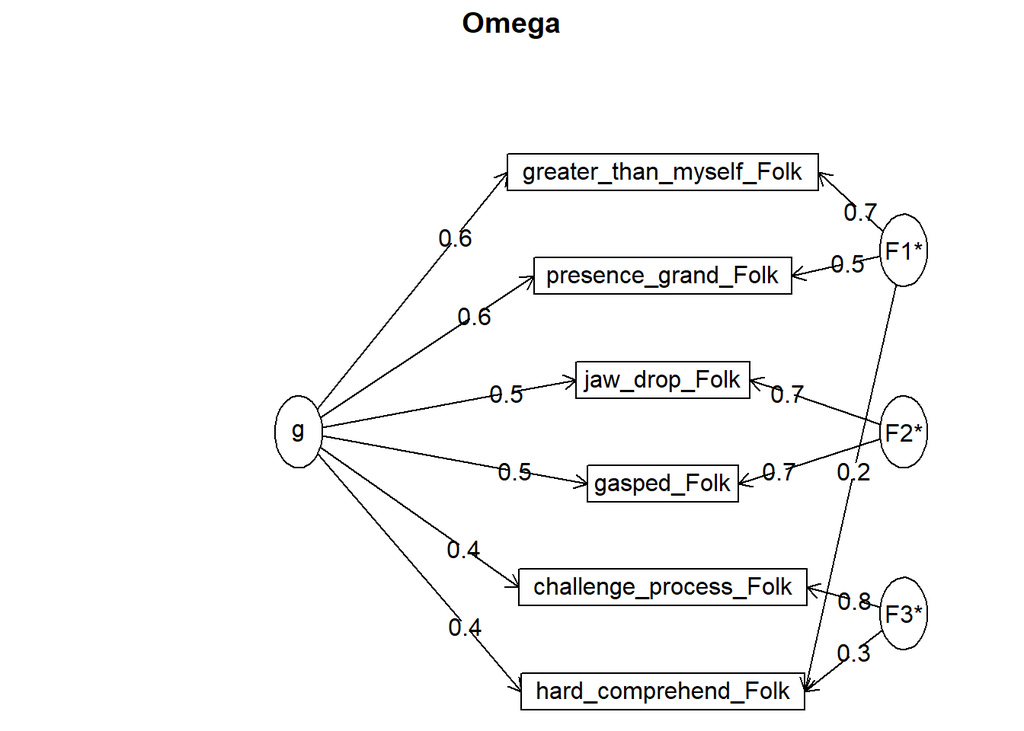

```
## Omega
## Call: omegah(m = m, nfactors = nfactors, fm = fm, key = key, flip = flip,
##     digits = digits, title = title, sl = sl, labels = labels,
##     plot = plot, n.obs = n.obs, rotate = rotate, Phi = Phi, option = option,
##     covar = covar)
## Alpha:                 0.79
## G.6:                   0.82
## Omega Hierarchical:    0.58
## Omega H asymptotic:    0.64
## Omega Total            0.9
##
## Schmid Leiman Factor loadings greater than  0.2
##                             g   F1*   F2*   F3*   h2   u2   p2
## presence_grand_Folk      0.61  0.52             0.66 0.34 0.57
## greater_than_myself_Folk 0.63  0.73             0.93 0.07 0.43
## jaw_drop_Folk            0.54        0.68       0.75 0.25 0.39
## gasped_Folk              0.54        0.66       0.73 0.27 0.40
## challenge_process_Folk   0.44              0.84 0.90 0.10 0.22
## hard_comprehend_Folk     0.42  0.23        0.34 0.35 0.65 0.51
##
## With Sums of squares  of:
##    g  F1*  F2*  F3*
## 1.73 0.85 0.92 0.82
##
## general/max  1.89   max/min =   1.12
## mean percent general =  0.42    with sd =  0.12 and cv of  0.29
## Explained Common Variance of the general factor =  0.4
##
## The degrees of freedom are 0  and the fit is  0
## The number of observations was  136  with Chi Square =  0  with prob <  NA
## The root mean square of the residuals is  0
## The df corrected root mean square of the residuals is  NA
##
## Compare this with the adequacy of just a general factor and no group factors
## The degrees of freedom for just the general factor are 9  and the fit is  1.01
## The number of observations was  136  with Chi Square =  132.81  with prob <  3.1e-24
## The root mean square of the residuals is  0.18
## The df corrected root mean square of the residuals is  0.23
##
## RMSEA index =  0.318  and the 10 % confidence intervals are  0.272 0.368
## BIC =  88.59
##
## Measures of factor score adequacy
##                                                  g  F1*  F2*  F3*
## Correlation of scores with factors            0.78 0.79 0.79 0.88
## Multiple R square of scores with factors      0.60 0.62 0.63 0.78
## Minimum correlation of factor score estimates 0.21 0.25 0.25 0.56
##
##  Total, General and Subset omega for each subset
##                                                  g  F1*  F2*  F3*
## Omega total for total scores and subscales    0.90 0.88 0.85 0.73
## Omega general for total scores and subscales  0.58 0.44 0.33 0.26
## Omega group for total scores and subscales    0.27 0.44 0.52 0.47
```

```r
omega(AWE)
```

### Admiration and Wonder

```r
awe_items<-c("presence_grand", "greater_than_myself", "jaw_drop", "gasped", "challenge_process", "hard_comprehend", "admiration")

df_awe<-df.full%>%select(Pt_ID, contains(awe_items))

df_awe.long<-df_awe%>%pivot_longer(!Pt_ID,
                        names_to = c("question", "piece"),
                        names_pattern ="(.*)_(.*)",
                        values_to = "response")

df_awe.wide<-df_awe.long%>%pivot_wider(names_from = question, values_from = response)
```

But this is maybe not accurate because it makes sense it would be higher when there are repeated measures. Therefore, check the piece-wise values.

```r
df_Aw<-df_awe.wide%>%select(-Pt_ID, -piece)
lowerCor(df_Aw)
```

```
##                     prsn_ grt__ jw_dr gaspd chll_ hrd_c admrt
## presence_grand      1.00
## greater_than_myself 0.73  1.00
## jaw_drop            0.35  0.32  1.00
## gasped              0.31  0.25  0.56  1.00
## challenge_process   0.27  0.22  0.19  0.15  1.00
## hard_comprehend     0.27  0.26  0.17  0.19  0.48  1.00
## admiration          0.57  0.54  0.25  0.26  0.14  0.16  1.00
```

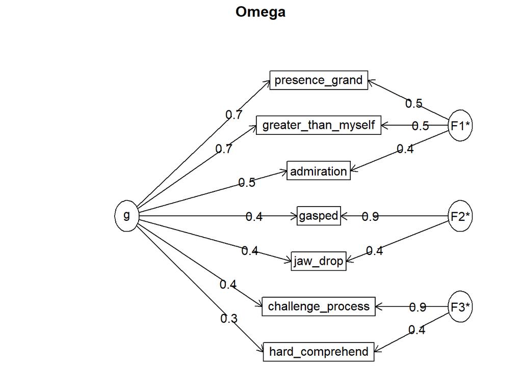

```
## Omega
## Call: omegah(m = m, nfactors = nfactors, fm = fm, key = key, flip = flip,
##     digits = digits, title = title, sl = sl, labels = labels,
##     plot = plot, n.obs = n.obs, rotate = rotate, Phi = Phi, option = option,
##     covar = covar)
## Alpha:                 0.77
## G.6:                   0.79
## Omega Hierarchical:    0.56
## Omega H asymptotic:    0.64
## Omega Total            0.88
##
## Schmid Leiman Factor loadings greater than  0.2
##                        g   F1*   F2*   F3*   h2   u2   p2
## presence_grand      0.70  0.53             0.77 0.23 0.63
## greater_than_myself 0.65  0.53             0.71 0.29 0.61
## jaw_drop            0.40        0.43       0.36 0.64 0.44
## gasped              0.44        0.89       1.00 0.00 0.20
## challenge_process   0.36              0.89 0.92 0.08 0.14
## hard_comprehend     0.31              0.42 0.28 0.72 0.35
## admiration          0.51  0.40             0.42 0.58 0.61
##
## With Sums of squares  of:
##    g  F1*  F2*  F3*
## 1.75 0.75 0.99 0.97
##
## general/max  1.77   max/min =   1.33
## mean percent general =  0.43    with sd =  0.2 and cv of  0.48
## Explained Common Variance of the general factor =  0.39
##
## The degrees of freedom are 3  and the fit is  0
## The number of observations was  408  with Chi Square =  2  with prob <  0.57
## The root mean square of the residuals is  0.01
## The df corrected root mean square of the residuals is  0.02
## RMSEA index =  0  and the 10 % confidence intervals are  0 0.072
## BIC =  -16.04
##
## Compare this with the adequacy of just a general factor and no group factors
## The degrees of freedom for just the general factor are 14  and the fit is  0.74
## The number of observations was  408  with Chi Square =  298.16  with prob <  2.9e-55
## The root mean square of the residuals is  0.15
## The df corrected root mean square of the residuals is  0.19
##
## RMSEA index =  0.223  and the 10 % confidence intervals are  0.202 0.246
## BIC =  214.01
##
## Measures of factor score adequacy
##                                                  g   F1*  F2*  F3*
## Correlation of scores with factors            0.78  0.63 0.95 0.92
## Multiple R square of scores with factors      0.61  0.40 0.89 0.85
## Minimum correlation of factor score estimates 0.23 -0.21 0.79 0.71
##
##  Total, General and Subset omega for each subset
##                                                  g  F1*  F2*  F3*
## Omega total for total scores and subscales    0.88 0.84 0.79 0.73
## Omega general for total scores and subscales  0.56 0.52 0.23 0.15
## Omega group for total scores and subscales    0.28 0.32 0.56 0.58
```

```r
omega(df_Aw)
```

#### Piece-wise

```r
#Beethoven
# Adjust the AWE response scale to 0-6 by subtracting 1 from every response
AWE_adjusted<-AWE_B[2:7]-1
AWE_adj<-cbind(AWE_B$Pt_ID, AWE_adjusted)
colnames(AWE_adj)[1]<-"Pt_ID"

# Add the admiration and wonder item to the dataframe
wonder<-df.full%>%select(Pt_ID, admiration_Beethoven)
AWE_wonder<-full_join(AWE_adj, wonder, by = "Pt_ID")

AWE_adj<-AWE_adj%>%select(-Pt_ID)
AWE_wonder<-AWE_wonder%>%select(-Pt_ID)
print(summary(psych::alpha(AWE_adj))$raw_alpha) # alpha = .66
```

```
##
## Reliability analysis
##  raw_alpha std.alpha G6(smc) average_r S/N   ase mean  sd median_r
##       0.66      0.67     0.7      0.25   2 0.046  2.9 1.1     0.23
## NULL
```

```r
print(summary(psych::alpha(AWE_wonder))$raw_alpha) # alpha = .72
```

```
##
## Reliability analysis
##  raw_alpha std.alpha G6(smc) average_r S/N   ase mean  sd median_r
##       0.72      0.73    0.75      0.28 2.7 0.037    3 1.1     0.23
## NULL
```

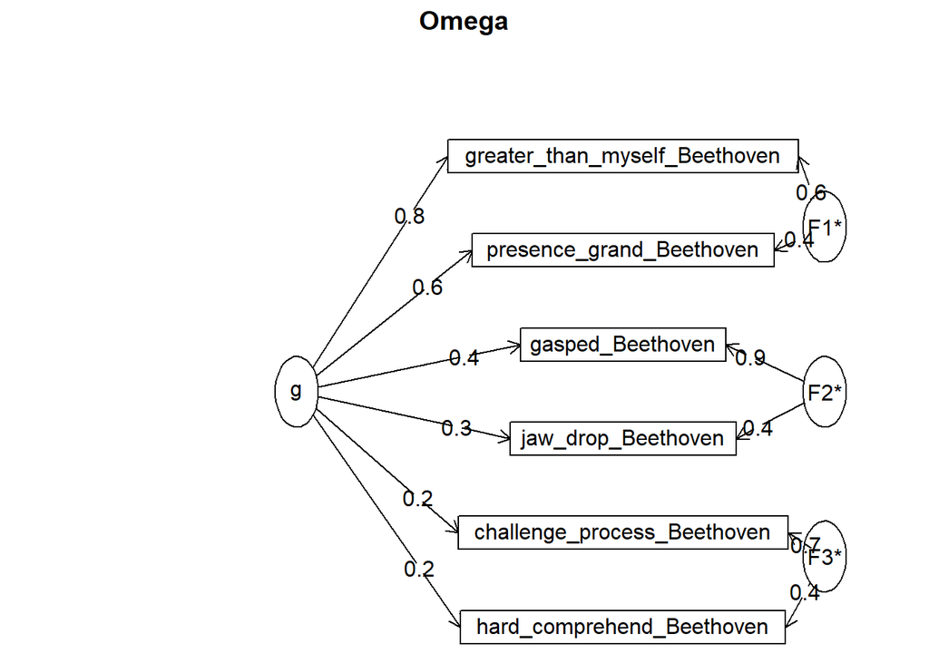

```
## Omega
## Call: omegah(m = m, nfactors = nfactors, fm = fm, key = key, flip = flip,
##     digits = digits, title = title, sl = sl, labels = labels,
##     plot = plot, n.obs = n.obs, rotate = rotate, Phi = Phi, option = option,
##     covar = covar)
## Alpha:                 0.67
## G.6:                   0.7
## Omega Hierarchical:    0.49
## Omega H asymptotic:    0.59
## Omega Total            0.82
##
## Schmid Leiman Factor loadings greater than  0.2
##                                  g   F1*   F2*   F3*   h2   u2   p2
## presence_grand_Beethoven      0.63  0.38             0.56 0.44 0.70
## greater_than_myself_Beethoven 0.80  0.56             0.97 0.03 0.67
## jaw_drop_Beethoven            0.28        0.42       0.27 0.73 0.30
## gasped_Beethoven              0.38        0.92       1.00 0.00 0.14
## challenge_process_Beethoven   0.25              0.71 0.56 0.44 0.11
## hard_comprehend_Beethoven     0.24              0.41 0.23 0.77 0.24
##
## With Sums of squares  of:
##    g  F1*  F2*  F3*
## 1.38 0.47 1.04 0.69
##
## general/max  1.33   max/min =   2.23
## mean percent general =  0.36    with sd =  0.26 and cv of  0.72
## Explained Common Variance of the general factor =  0.39
##
## The degrees of freedom are 0  and the fit is  0
## The number of observations was  136  with Chi Square =  0.16  with prob <  NA
## The root mean square of the residuals is  0.01
## The df corrected root mean square of the residuals is  NA
##
## Compare this with the adequacy of just a general factor and no group factors
## The degrees of freedom for just the general factor are 9  and the fit is  0.46
## The number of observations was  136  with Chi Square =  60.71  with prob <  9.8e-10
## The root mean square of the residuals is  0.14
## The df corrected root mean square of the residuals is  0.18
##
## RMSEA index =  0.205  and the 10 % confidence intervals are  0.159 0.257
## BIC =  16.5
##
## Measures of factor score adequacy
##                                                  g   F1*  F2*  F3*
## Correlation of scores with factors            0.83  0.60 0.97 0.76
## Multiple R square of scores with factors      0.68  0.36 0.94 0.58
## Minimum correlation of factor score estimates 0.37 -0.28 0.88 0.15
##
##  Total, General and Subset omega for each subset
##                                                  g  F1*  F2*  F3*
## Omega total for total scores and subscales    0.82 0.86 0.75 0.55
## Omega general for total scores and subscales  0.49 0.60 0.15 0.09
## Omega group for total scores and subscales    0.29 0.26 0.61 0.46
```

```r
omega(AWE_adj) #omega = .82
```

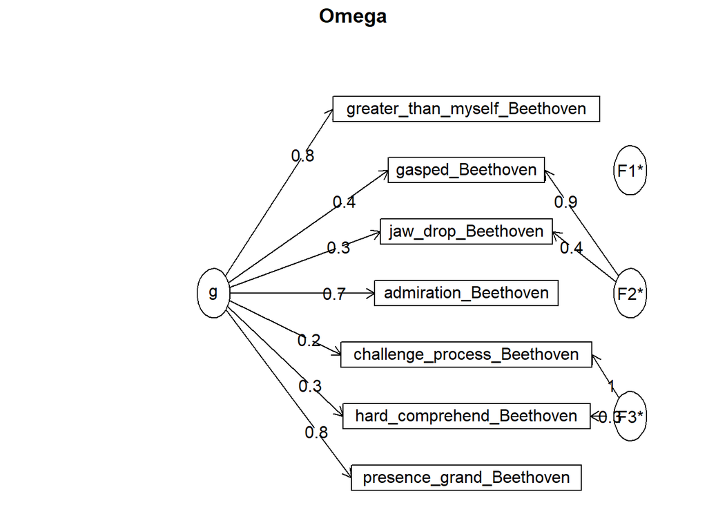

```
## Omega
## Call: omegah(m = m, nfactors = nfactors, fm = fm, key = key, flip = flip,
##     digits = digits, title = title, sl = sl, labels = labels,
##     plot = plot, n.obs = n.obs, rotate = rotate, Phi = Phi, option = option,
##     covar = covar)
## Alpha:                 0.73
## G.6:                   0.75
## Omega Hierarchical:    0.66
## Omega H asymptotic:    0.78
## Omega Total            0.86
##
## Schmid Leiman Factor loadings greater than  0.2
##                                  g   F1*   F2*   F3*   h2   u2   p2
## presence_grand_Beethoven      0.83                   0.70 0.30 0.99
## greater_than_myself_Beethoven 0.85                   0.72 0.28 0.99
## jaw_drop_Beethoven            0.29        0.42       0.26 0.74 0.31
## gasped_Beethoven              0.36        0.93       1.00 0.00 0.13
## challenge_process_Beethoven   0.23              0.97 1.00 0.00 0.05
## hard_comprehend_Beethoven     0.26              0.29 0.16 0.84 0.44
## admiration_Beethoven          0.69                   0.49 0.51 0.99
##
## With Sums of squares  of:
##    g  F1*  F2*  F3*
## 2.23 0.01 1.05 1.03
##
## general/max  2.12   max/min =   151.32
## mean percent general =  0.56    with sd =  0.42 and cv of  0.76
## Explained Common Variance of the general factor =  0.52
##
## The degrees of freedom are 3  and the fit is  0.01
## The number of observations was  136  with Chi Square =  1.6  with prob <  0.66
## The root mean square of the residuals is  0.01
## The df corrected root mean square of the residuals is  0.03
## RMSEA index =  0  and the 10 % confidence intervals are  0 0.114
## BIC =  -13.13
##
## Compare this with the adequacy of just a general factor and no group factors
## The degrees of freedom for just the general factor are 14  and the fit is  0.35
## The number of observations was  136  with Chi Square =  46.3  with prob <  2.5e-05
## The root mean square of the residuals is  0.11
## The df corrected root mean square of the residuals is  0.13
##
## RMSEA index =  0.13  and the 10 % confidence intervals are  0.09 0.173
## BIC =  -22.48
##
## Measures of factor score adequacy
##                                                  g   F1*  F2*  F3*
## Correlation of scores with factors            0.93  0.06 0.99 0.99
## Multiple R square of scores with factors      0.86  0.00 0.98 0.99
## Minimum correlation of factor score estimates 0.71 -0.99 0.95 0.98
##
##  Total, General and Subset omega for each subset
##                                                  g  F1*  F2*  F3*
## Omega total for total scores and subscales    0.86 0.72 0.75 0.76
## Omega general for total scores and subscales  0.66 0.72 0.36 0.38
## Omega group for total scores and subscales    0.20 0.00 0.39 0.38
```

```r
omega(AWE_wonder) #omega = .86 (but ruined the factor structure)
```

```r
#Schnittke
# Adjust the AWE response scale to 0-6 by subtracting 1 from every response
AWE_adjusted<-AWE_S[2:7]-1
AWE_adj<-cbind(AWE_S$Pt_ID, AWE_adjusted)
colnames(AWE_adj)[1]<-"Pt_ID"

# Add the admiration and wonder item to the dataframe
wonder<-df.full%>%select(Pt_ID, admiration_Schnittke)
AWE_wonder<-full_join(AWE_adj, wonder, by = "Pt_ID")

AWE_adj<-AWE_adj%>%select(-Pt_ID)
AWE_wonder<-AWE_wonder%>%select(-Pt_ID)
print(summary(psych::alpha(AWE_adj))$raw_alpha) # alpha = .72
```

```
##
## Reliability analysis
##  raw_alpha std.alpha G6(smc) average_r S/N   ase mean  sd median_r
##       0.72      0.72    0.76       0.3 2.6 0.038  3.1 1.2     0.25
## NULL
```

```r
print(summary(psych::alpha(AWE_wonder))$raw_alpha) # alpha = .75
```

```
##
## Reliability analysis
##  raw_alpha std.alpha G6(smc) average_r S/N   ase mean  sd median_r
##       0.75      0.75    0.79       0.3 3.1 0.034  3.3 1.2     0.23
## NULL
```

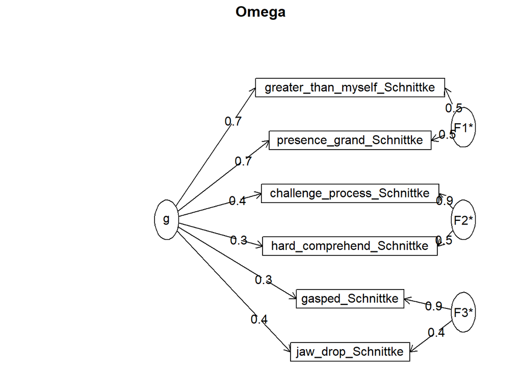

```
## Omega
## Call: omegah(m = m, nfactors = nfactors, fm = fm, key = key, flip = flip,
##     digits = digits, title = title, sl = sl, labels = labels,
##     plot = plot, n.obs = n.obs, rotate = rotate, Phi = Phi, option = option,
##     covar = covar)
## Alpha:                 0.72
## G.6:                   0.76
## Omega Hierarchical:    0.51
## Omega H asymptotic:    0.58
## Omega Total            0.88
##
## Schmid Leiman Factor loadings greater than  0.2
##                                  g   F1*   F2*   F3*   h2   u2   p2
## presence_grand_Schnittke      0.71  0.46             0.73 0.27 0.70
## greater_than_myself_Schnittke 0.71  0.50             0.76 0.24 0.66
## jaw_drop_Schnittke            0.42              0.36 0.35 0.65 0.51
## gasped_Schnittke              0.31              0.95 1.00 0.00 0.10
## challenge_process_Schnittke   0.36        0.93       1.00 0.00 0.13
## hard_comprehend_Schnittke     0.25        0.48       0.30 0.70 0.21
##
## With Sums of squares  of:
##   g F1* F2* F3*
## 1.5 0.5 1.1 1.0
##
## general/max  1.32   max/min =   2.24
## mean percent general =  0.38    with sd =  0.27 and cv of  0.7
## Explained Common Variance of the general factor =  0.36
##
## The degrees of freedom are 0  and the fit is  0
## The number of observations was  136  with Chi Square =  0.18  with prob <  NA
## The root mean square of the residuals is  0
## The df corrected root mean square of the residuals is  NA
##
## Compare this with the adequacy of just a general factor and no group factors
## The degrees of freedom for just the general factor are 9  and the fit is  0.66
## The number of observations was  136  with Chi Square =  87.19  with prob <  6e-15
## The root mean square of the residuals is  0.17
## The df corrected root mean square of the residuals is  0.22
##
## RMSEA index =  0.253  and the 10 % confidence intervals are  0.207 0.304
## BIC =  42.98
##
## Measures of factor score adequacy
##                                                  g   F1*  F2*  F3*
## Correlation of scores with factors            0.79  0.56 0.97 0.98
## Multiple R square of scores with factors      0.63  0.31 0.93 0.95
## Minimum correlation of factor score estimates 0.25 -0.38 0.87 0.91
##
##  Total, General and Subset omega for each subset
##                                                  g  F1*  F2*  F3*
## Omega total for total scores and subscales    0.88 0.85 0.77 0.76
## Omega general for total scores and subscales  0.51 0.58 0.12 0.18
## Omega group for total scores and subscales    0.31 0.27 0.65 0.58
```

```r
omega(AWE_adj) #omega = .88
```

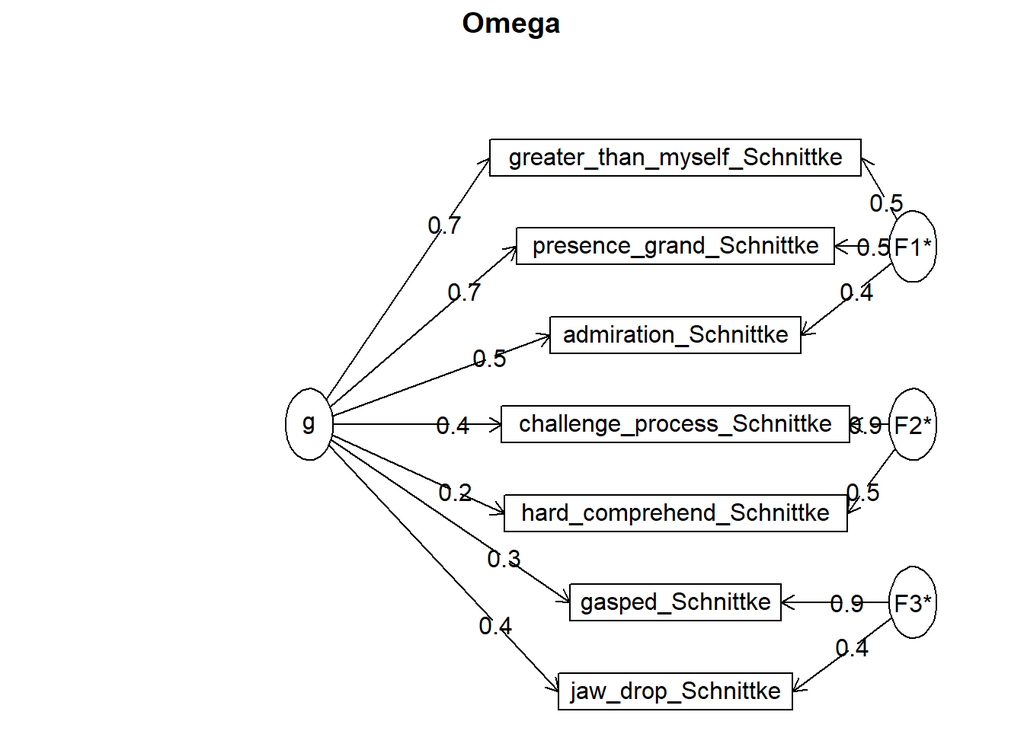

```
## Omega
## Call: omegah(m = m, nfactors = nfactors, fm = fm, key = key, flip = flip,
##     digits = digits, title = title, sl = sl, labels = labels,
##     plot = plot, n.obs = n.obs, rotate = rotate, Phi = Phi, option = option,
##     covar = covar)
## Alpha:                 0.75
## G.6:                   0.79
## Omega Hierarchical:    0.55
## Omega H asymptotic:    0.63
## Omega Total            0.88
##
## Schmid Leiman Factor loadings greater than  0.2
##                                  g   F1*   F2*   F3*   h2   u2   p2
## presence_grand_Schnittke      0.74  0.47             0.77 0.23 0.71
## greater_than_myself_Schnittke 0.70  0.49             0.73 0.27 0.67
## jaw_drop_Schnittke            0.41              0.36 0.34 0.66 0.49
## gasped_Schnittke              0.31              0.95 1.00 0.00 0.10
## challenge_process_Schnittke   0.36        0.93       0.99 0.01 0.13
## hard_comprehend_Schnittke     0.25        0.49       0.31 0.69 0.20
## admiration_Schnittke          0.55  0.38             0.44 0.56 0.68
##
## With Sums of squares  of:
##    g  F1*  F2*  F3*
## 1.79 0.62 1.13 1.04
##
## general/max  1.59   max/min =   1.81
## mean percent general =  0.43    with sd =  0.28 and cv of  0.65
## Explained Common Variance of the general factor =  0.39
##
## The degrees of freedom are 3  and the fit is  0.02
## The number of observations was  136  with Chi Square =  1.95  with prob <  0.58
## The root mean square of the residuals is  0.01
## The df corrected root mean square of the residuals is  0.03
## RMSEA index =  0  and the 10 % confidence intervals are  0 0.123
## BIC =  -12.79
##
## Compare this with the adequacy of just a general factor and no group factors
## The degrees of freedom for just the general factor are 14  and the fit is  0.74
## The number of observations was  136  with Chi Square =  96.93  with prob <  1.8e-14
## The root mean square of the residuals is  0.15
## The df corrected root mean square of the residuals is  0.19
##
## RMSEA index =  0.209  and the 10 % confidence intervals are  0.171 0.25
## BIC =  28.16
##
## Measures of factor score adequacy
##                                                  g   F1*  F2*  F3*
## Correlation of scores with factors            0.80  0.56 0.97 0.98
## Multiple R square of scores with factors      0.64  0.31 0.94 0.95
## Minimum correlation of factor score estimates 0.29 -0.38 0.88 0.91
##
##  Total, General and Subset omega for each subset
##                                                  g  F1*  F2*  F3*
## Omega total for total scores and subscales    0.88 0.84 0.77 0.76
## Omega general for total scores and subscales  0.55 0.58 0.12 0.18
## Omega group for total scores and subscales    0.28 0.26 0.65 0.59
```

```r
omega(AWE_wonder) #omega = .88 (admiration was added to the factor of grandness)
```

```r
#Folk
# Adjust the AWE response scale to 0-6 by subtracting 1 from every response
AWE_adjusted<-AWE_F[2:7]-1
AWE_adj<-cbind(AWE_F$Pt_ID, AWE_adjusted)
colnames(AWE_adj)[1]<-"Pt_ID"

# Add the admiration and wonder item to the dataframe
wonder<-df.full%>%select(Pt_ID, admiration_Folk)
AWE_wonder<-full_join(AWE_adj, wonder, by = "Pt_ID")

AWE_adj<-AWE_adj%>%select(-Pt_ID)
AWE_wonder<-AWE_wonder%>%select(-Pt_ID)
print(summary(psych::alpha(AWE_adj))$raw_alpha) # alpha = .79
```

```
##
## Reliability analysis
##  raw_alpha std.alpha G6(smc) average_r S/N   ase mean  sd median_r
##       0.79      0.79    0.83      0.39 3.8 0.028  2.5 1.2     0.31
## NULL
```

```r
print(summary(psych::alpha(AWE_wonder))$raw_alpha) # alpha = .81
```

```
##
## Reliability analysis
##  raw_alpha std.alpha G6(smc) average_r S/N   ase mean  sd median_r
##       0.81      0.81    0.84      0.37 4.2 0.026  2.7 1.2     0.32
## NULL
```

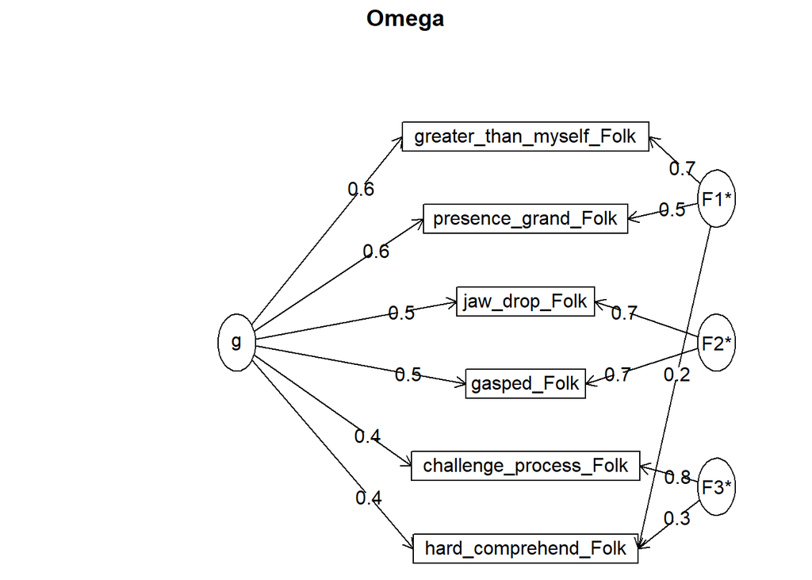

```
## Omega
## Call: omegah(m = m, nfactors = nfactors, fm = fm, key = key, flip = flip,
##     digits = digits, title = title, sl = sl, labels = labels,
##     plot = plot, n.obs = n.obs, rotate = rotate, Phi = Phi, option = option,
##     covar = covar)
## Alpha:                 0.79
## G.6:                   0.82
## Omega Hierarchical:    0.58
## Omega H asymptotic:    0.64
## Omega Total            0.9
##
## Schmid Leiman Factor loadings greater than  0.2
##                             g   F1*   F2*   F3*   h2   u2   p2
## presence_grand_Folk      0.61  0.52             0.66 0.34 0.57
## greater_than_myself_Folk 0.63  0.73             0.93 0.07 0.43
## jaw_drop_Folk            0.54        0.68       0.75 0.25 0.39
## gasped_Folk              0.54        0.66       0.73 0.27 0.40
## challenge_process_Folk   0.44              0.84 0.90 0.10 0.22
## hard_comprehend_Folk     0.42  0.23        0.34 0.35 0.65 0.51
##
## With Sums of squares  of:
##    g  F1*  F2*  F3*
## 1.73 0.85 0.92 0.82
##
## general/max  1.89   max/min =   1.12
## mean percent general =  0.42    with sd =  0.12 and cv of  0.29
## Explained Common Variance of the general factor =  0.4
##
## The degrees of freedom are 0  and the fit is  0
## The number of observations was  136  with Chi Square =  0  with prob <  NA
## The root mean square of the residuals is  0
## The df corrected root mean square of the residuals is  NA
##
## Compare this with the adequacy of just a general factor and no group factors
## The degrees of freedom for just the general factor are 9  and the fit is  1.01
## The number of observations was  136  with Chi Square =  132.81  with prob <  3.1e-24
## The root mean square of the residuals is  0.18
## The df corrected root mean square of the residuals is  0.23
##
## RMSEA index =  0.318  and the 10 % confidence intervals are  0.272 0.368
## BIC =  88.59
##
## Measures of factor score adequacy
##                                                  g  F1*  F2*  F3*
## Correlation of scores with factors            0.78 0.79 0.79 0.88
## Multiple R square of scores with factors      0.60 0.62 0.63 0.78
## Minimum correlation of factor score estimates 0.21 0.25 0.25 0.56
##
##  Total, General and Subset omega for each subset
##                                                  g  F1*  F2*  F3*
## Omega total for total scores and subscales    0.90 0.88 0.85 0.73
## Omega general for total scores and subscales  0.58 0.44 0.33 0.26
## Omega group for total scores and subscales    0.27 0.44 0.52 0.47
```

```r
omega(AWE_adj) #omega = .9
```

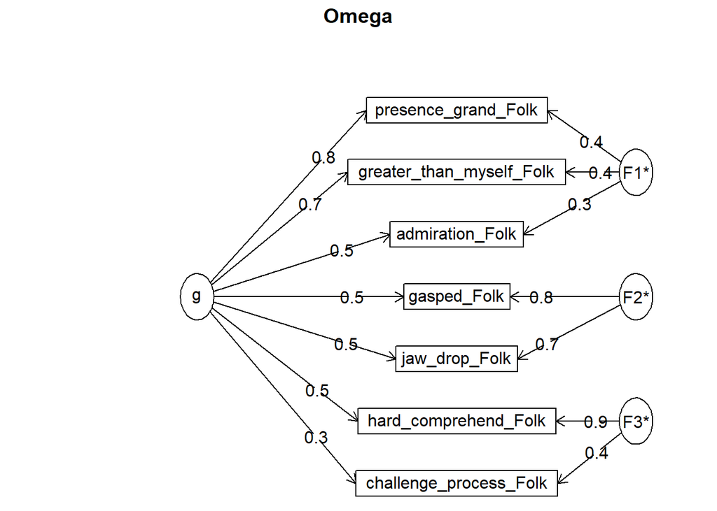

```
## Omega
## Call: omegah(m = m, nfactors = nfactors, fm = fm, key = key, flip = flip,
##     digits = digits, title = title, sl = sl, labels = labels,
##     plot = plot, n.obs = n.obs, rotate = rotate, Phi = Phi, option = option,
##     covar = covar)
## Alpha:                 0.81
## G.6:                   0.84
## Omega Hierarchical:    0.67
## Omega H asymptotic:    0.75
## Omega Total            0.9
##
## Schmid Leiman Factor loadings greater than  0.2
##                             g   F1*   F2*   F3*   h2   u2   p2
## presence_grand_Folk      0.84  0.40             0.86 0.14 0.81
## greater_than_myself_Folk 0.73  0.35             0.67 0.33 0.80
## jaw_drop_Folk            0.48        0.67       0.68 0.32 0.34
## gasped_Folk              0.48        0.76       0.81 0.19 0.29
## challenge_process_Folk   0.33              0.35 0.25 0.75 0.45
## hard_comprehend_Folk     0.49              0.87 1.00 0.00 0.24
## admiration_Folk          0.54  0.26             0.38 0.62 0.77
##
## With Sums of squares  of:
##    g  F1*  F2*  F3*
## 2.35 0.35 1.05 0.89
##
## general/max  2.24   max/min =   2.95
## mean percent general =  0.53    with sd =  0.26 and cv of  0.48
## Explained Common Variance of the general factor =  0.51
##
## The degrees of freedom are 3  and the fit is  0.01
## The number of observations was  136  with Chi Square =  1.12  with prob <  0.77
## The root mean square of the residuals is  0.01
## The df corrected root mean square of the residuals is  0.02
## RMSEA index =  0  and the 10 % confidence intervals are  0 0.097
## BIC =  -13.62
##
## Compare this with the adequacy of just a general factor and no group factors
## The degrees of freedom for just the general factor are 14  and the fit is  0.88
## The number of observations was  136  with Chi Square =  116.02  with prob <  3.8e-18
## The root mean square of the residuals is  0.14
## The df corrected root mean square of the residuals is  0.18
##
## RMSEA index =  0.231  and the 10 % confidence intervals are  0.194 0.272
## BIC =  47.24
##
## Measures of factor score adequacy
##                                                  g   F1*  F2*  F3*
## Correlation of scores with factors            0.88  0.49 0.87 0.96
## Multiple R square of scores with factors      0.77  0.24 0.75 0.92
## Minimum correlation of factor score estimates 0.54 -0.52 0.50 0.84
##
##  Total, General and Subset omega for each subset
##                                                  g  F1*  F2*  F3*
## Omega total for total scores and subscales    0.90 0.83 0.85 0.74
## Omega general for total scores and subscales  0.67 0.68 0.27 0.23
## Omega group for total scores and subscales    0.20 0.16 0.58 0.51
```

```r
omega(AWE_wonder) #omega = .9 (admiration was added to the grandness factor)
```

## Missing values

To avoid losing participants with missing values, consider imputing values to the median. There was one live participant who did not report their fan-status therefore they were imputed to the median.

```r
df.full$fan[df.full$group == "Live" &is.na(df.full$fan)]<-median(df.full$fan, na.rm = TRUE)
df.full$fan
```

```
##   [1]  1  1  6  5  6  7  1  5  7  1  1  1  7  6  4  7  4  7  6  7  7  6  6  7  3
##  [26]  7  7  7  1  7  7  3  6  7  4  6  7  7  7  5  6  7  6  7  7  1  1  6  1  7
##  [51]  7  7  6  7  6  7  7  6  7  7  7  7  1  6  6  7  7  7  7  6  7  7  7  7  5
##  [76]  6  7  7  6  7  7  3  1  6  7  7  5  7  7  7  1  1  1  7  1  7  1  1  1  1
## [101]  7  4  1  5  7  5  7  4  7  1  4  6  1  1  1  4  1  7 NA  1  7  7  5 NA NA
## [126] NA  1 NA  7 NA NA NA  4 NA NA NA
```

AIMS is the only variable that we may want to include in the models that is potentially missing while all the others are there because it was collected in the post-concert survey while the others were collected in the pre-concert survey.

```r
personal_chars<-df.full%>%select(Pt_ID, fan, EC, AIMS, musician_status, Watch_Alone, personal_relation, contains("connected"))
personal_chars_w_na = personal_chars[!complete.cases(personal_chars), ]
pts_to_impute<-personal_chars_w_na%>%filter(is.na(AIMS))%>%filter(!is.na(connected_musicians_Beethoven)|!is.na(connected_musicians_Schnittke)| !is.na(connected_musicians_Folk)|!is.na(connected_audience_Beethoven)|!is.na(connected_audience_Schnittke)|!is.na(connected_audience_attending_Folk))%>%filter(!is.na(personal_relation)) # but having at least one connectedness value
# there are 10 cases where AIMS is missing but they have the other values & at least one report of connectedness

median_aims<-median(df.full$AIMS, na.rm = TRUE)
median_fan<-median(df.full$fan, na.rm = TRUE)

df.full$AIMS[df.full$Pt_ID %in% pts_to_impute$Pt_ID]<-median_aims

# check that it worked = yes!
df.full%>%filter(Pt_ID %in% pts_to_impute$Pt_ID)%>%select(AIMS)
```

```
## # A tibble: 10 × 1
##     AIMS
##    <dbl>
##  1   117
##  2   117
##  3   117
##  4   117
##  5   117
##  6   117
##  7   117
##  8   117
##  9   117
## 10   117
```

```r
pts_to_impute%>%select(Pt_ID, fan, AIMS)
```

```
## # A tibble: 10 × 3
##    Pt_ID    fan  AIMS
##    <chr>  <dbl> <dbl>
##  1 BEQ118     1    NA
##  2 BEU128     7    NA
##  3 BEQ117     5    NA
##  4 BES123     1    NA
##  5 BES124     1    NA
##  6 BEQ116     1    NA
##  7 BEU130    NA    NA
##  8 BEU129     1    NA
##  9 BDQ093     5    NA
## 10 BEQ115     4    NA
```

```r
#there is one case where they have the other values but not AIMS and fan (Pt_ID = BEU130). Therefore I propose filling in AIMS and fan-status for that one person.

df.full$fan[df.full$Pt_ID == "BEU130"]<-median_fan
```

Combine group size and watch alone by assigning virtual participants who said they did not watch alone a value of 2.

```r
#group_size is NA for livestreaming Ps
df.full$group_size[df.full$Watch_Alone==1 & df.full$group =="Virtual"]<-1
df.full$group_size[df.full$Watch_Alone==0 & df.full$group =="Virtual"]<-2

# check that this worked correctly
df.full%>%select(Pt_ID, Watch_Alone,viewing_with_others, group_size)
```

```
## # A tibble: 136 × 4
##    Pt_ID  Watch_Alone viewing_with_others group_size
##    <chr>        <dbl> <fct>                    <dbl>
##  1 AEQ086           0 <NA>                         3
##  2 AEU091           0 <NA>                         3
##  3 AEQ088           0 <NA>                         4
##  4 AEQ077           1 <NA>                         2
##  5 AEQ081           0 <NA>                         2
##  6 AEQ079           0 <NA>                         3
##  7 AEQ084           0 <NA>                         3
##  8 AER090           0 <NA>                         3
##  9 AEQ082           0 <NA>                         2
## 10 AEQ089           0 <NA>                         3
## # … with 126 more rows
```

# 3.3 Effect of Concert and Individual Characteristics on Emotions

## 3.3.1 Social Connectedness

### Audience attending vs. streaming

Check for difference between virtual audience connectedness towards the livestreaming versus the physically present audience.

First check whether there is a significant difference between reports of connectedness towards the physically present audience and the streaming audience.

IV: question (group directed connectedness - categorical - physically present versus streaming) DV: Connectedness value (ordinal). Test: Kruskal Wallis test

#### Visualize

…and examine means

```r
virtual_connectedness<-df.full%>%select(Pt_ID, group, contains(c("connected_audience_streaming", "connected_audience_attending")))%>%filter(group == "Virtual")


virtual_connectedness.long<-virtual_connectedness%>%pivot_longer(!c(group, Pt_ID), #make long
                        names_to = c("question", "piece"),
                        names_pattern ="(.*)_(.*)",
                        values_to = "response")

virtual_connectedness.long$question<-factor(virtual_connectedness.long$question, levels = c("connected_audience_attending", "connected_audience_streaming"), labels = c("Attending", "Streaming"))

#average connectedness audience attending
virtual_connectedness.long%>%group_by(group, question)%>%summarise(mean = mean(response, na.rm = TRUE), sd = sd(response, na.rm = TRUE))
```

```
## # A tibble: 2 × 4
## # Groups:   group [1]
##   group   question   mean    sd
##   <fct>   <fct>     <dbl> <dbl>
## 1 Virtual Attending  1.27  1.62
## 2 Virtual Streaming  1.55  1.78
```

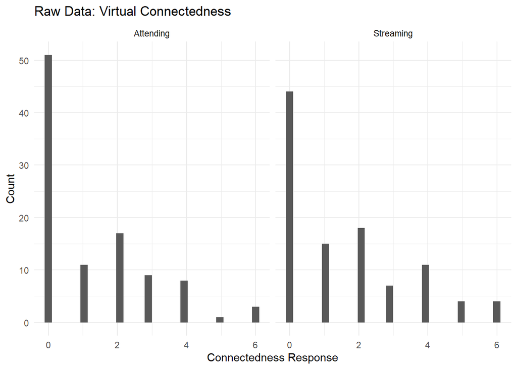

```r
# factor order
virtual_connectedness.long$piece<-factor(virtual_connectedness.long$piece, levels = c("Beethoven", "Schnittke", "Folk"))

virtual_connectedness.long%>%drop_na()%>%ggplot(aes(response))+
  geom_histogram()+facet_wrap(~question)+
  theme_minimal()+
  labs(title = "Raw Data: Virtual Connectedness", y = "Count", x = "Connectedness Response")
```

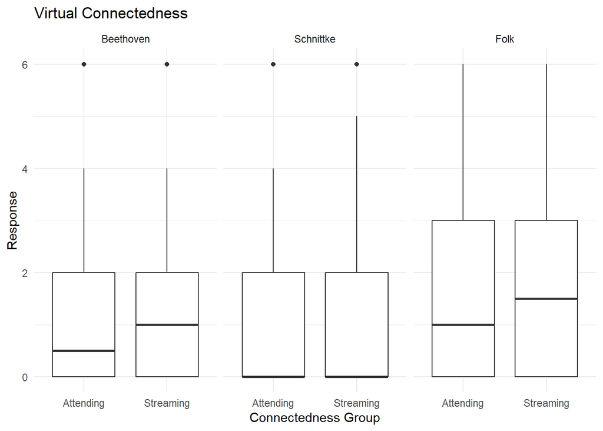

```r
virtual_connectedness.long%>%drop_na()%>%ggplot(aes(y = response, x = question))+
  geom_boxplot()+facet_wrap(~piece)+
  theme_minimal()+
  labs(title = "Virtual Connectedness", y = "Response", x = "Connectedness Group")
```

Based on the means it looks like the evaluations of connectedness were very similar, with the streaming group receiving very slightly greater assessments of connectedness than the attending audience.

To assess if there was a trend in the direction of the effect, we can also try plotting a line graph that would let us see this (similar to the comparison between moved and touched)

#### Visualize individuals

… differences in reports of connectedness towards the streaming and attending audience

There don’t seem to be any consistent differences with some people reporting more, some less, and some the same connectedness to each group.

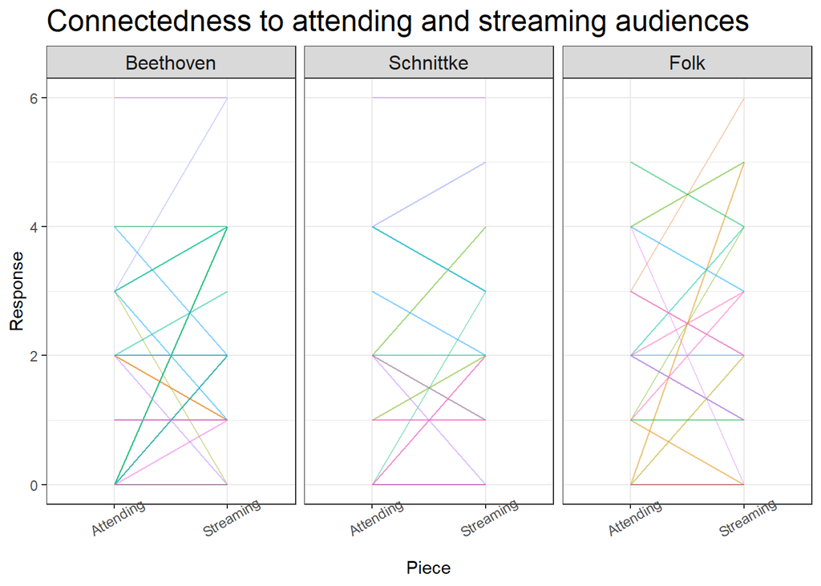

```r
virtual_connectedness.long$piece<-factor(virtual_connectedness.long$piece, levels = c("Beethoven", "Schnittke", "Folk"))

virtual_connectedness.long%>%
  ggplot(aes(color = Pt_ID,x = question, y = response, group = Pt_ID))+
  geom_line(alpha = 0.5)+ # in this way the darkness oft he line indicates the number of overlaping lines
  labs(title="Connectedness to attending and streaming audiences")+
  theme_bw()+
  xlab("Piece")+
  ylab("Response")+
  theme(axis.text.x = element_text(angle = 30))+
  theme(plot.title = element_text(size = 18))+
  theme(legend.position = "none")+
  facet_grid(~piece)+
  theme(strip.text.x = element_text(size = 12), strip.text.y = element_text(size = 12))
```

#### Test

… for differences between livestreaming participants SC towards live and livestreaming audiences

```r
# all data
all_data = kruskal.test(response ~ question,
             data = virtual_connectedness.long)

print(all_data)
```

```
##
##  Kruskal-Wallis rank sum test
##
## data:  response by question
## Kruskal-Wallis chi-squared = 1.3891, df = 1, p-value = 0.2385
```

```r
# beethoven
beeth_conn_virt<-virtual_connectedness.long%>%filter(piece == "Beethoven")
beethoven = kruskal.test(response ~ question,
             data = beeth_conn_virt)

print(beethoven)
```

```
##
##  Kruskal-Wallis rank sum test
##
## data:  response by question
## Kruskal-Wallis chi-squared = 1.042, df = 1, p-value = 0.3074
```

```r
# schnittke
schnit_conn_virt<-virtual_connectedness.long%>%filter(piece == "Schnittke")
schnittke = kruskal.test(response ~ question,
             data = schnit_conn_virt)

print(schnittke)
```

```
##
##  Kruskal-Wallis rank sum test
##
## data:  response by question
## Kruskal-Wallis chi-squared = 0.36625, df = 1, p-value = 0.5451
```

```r
# folk
folk_conn_virt<-virtual_connectedness.long%>%filter(piece == "Folk")
folk = kruskal.test(response ~ question,
             data = folk_conn_virt)

print(folk)
```

```
##
##  Kruskal-Wallis rank sum test
##
## data:  response by question
## Kruskal-Wallis chi-squared = 0.17472, df = 1, p-value = 0.6759
```

#### Organize data

```r
dat<-df.full%>%select(Pt_ID, group, contains("connected"))

# select the connected_musicians and connected_audience_attending
virt.dat<-dat%>%filter(group == "Virtual")%>%select(Pt_ID, group, contains("connected_musicians"), contains("connected_audience_streaming")) # contains("connected_audience_attending"))
colnames(virt.dat)
```

```
## [1] "Pt_ID"
## [2] "group"
## [3] "connected_musicians_Beethoven"
## [4] "connected_musicians_Schnittke"
## [5] "connected_musicians_Folk"
## [6] "connected_audience_streaming_Beethoven"
## [7] "connected_audience_streaming_Schnittke"
## [8] "connected_audience_streaming_Folk"
```

```r
live.dat<-dat%>%filter(group == "Live")%>%select(Pt_ID, group, contains("connected_musicians"), connected_audience_Beethoven, connected_audience_Schnittke, connected_audience_Folk)
colnames(live.dat)
```

```
## [1] "Pt_ID"                         "group"
## [3] "connected_musicians_Beethoven" "connected_musicians_Schnittke"
## [5] "connected_musicians_Folk"      "connected_audience_Beethoven"
## [7] "connected_audience_Schnittke"  "connected_audience_Folk"
```

```r
colnames(virt.dat)<-colnames(live.dat)

df<-bind_rows(live.dat, virt.dat)

df.long<-df%>%pivot_longer(!c(group, Pt_ID), #make long
                        names_to = c("question", "piece"),
                        names_pattern ="(.*)_(.*)",
                        values_to = "response")

df.long$piece<-factor(df.long$piece, levels = c("Beethoven", "Schnittke", "Folk")) #factor for the correct facet order

data<-df.long%>%drop_na() # removed NA so 816 observations became 726 observations

# data<-data%>%mutate_all(factor)
data$question<-as.factor(data$question)
data$Pt_ID<-as.factor(data$Pt_ID)
data$response.f<-factor(data$response, ordered = TRUE)
```

```r
personal_chars<-df.full%>%select(Pt_ID, fan, EC, AIMS, musician_status, group_size, personal_relation)

data_indchar<-data%>%left_join(personal_chars, by = "Pt_ID")

data_indchar_w_na = data_indchar[!complete.cases(data_indchar), ]

data_indchar_w_na%>%group_by(Pt_ID)%>%summarise(count = n()) # 10 participants being dropped all virtual
```

```
## # A tibble: 10 × 2
##    Pt_ID  count
##    <chr>  <int>
##  1 BDQ092     4
##  2 BEQ095     6
##  3 BEQ102     6
##  4 BEQ114     4
##  5 BnQ131     4
##  6 BnQ132     6
##  7 BnQ133     2
##  8 BnS134     4
##  9 BnS135     6
## 10 BnS136     4
```

```r
data_indchar%<>%drop_na()
# data --> data_indchar: 726 obs --> 680

data_indchar$Pt_ID<-factor(data_indchar$Pt_ID)
data_indchar$mus_stat_num = as.numeric(data_indchar$musician_status)

# check sample size
data_indchar%>%group_by(group, question,piece)%>%count()
```

```
## # A tibble: 12 × 4
## # Groups:   group, question, piece [12]
##    group   question            piece         n
##    <fct>   <fct>               <fct>     <int>
##  1 Live    connected_audience  Beethoven    89
##  2 Live    connected_audience  Schnittke    83
##  3 Live    connected_audience  Folk         88
##  4 Live    connected_musicians Beethoven    89
##  5 Live    connected_musicians Schnittke    83
##  6 Live    connected_musicians Folk         87
##  7 Virtual connected_audience  Beethoven    32
##  8 Virtual connected_audience  Schnittke    26
##  9 Virtual connected_audience  Folk         22
## 10 Virtual connected_musicians Beethoven    32
## 11 Virtual connected_musicians Schnittke    26
## 12 Virtual connected_musicians Folk         23
```

```r
check_outliers(data_indchar$response)
```

```
## OK: No outliers detected.
## - Based on the following method and threshold: zscore_robust (3.09).
## - For variable: data_indchar$response
```

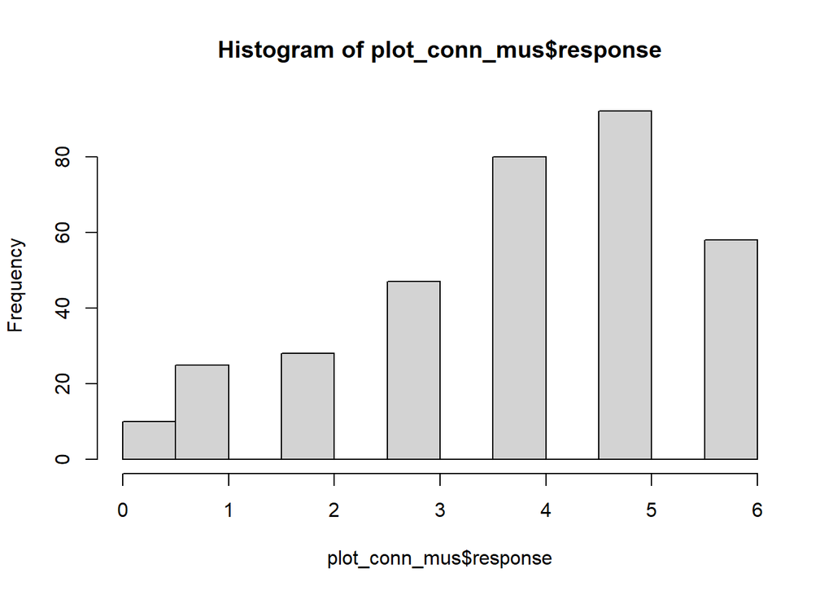

```r
plot_conn_mus<-data_indchar%>%filter(question == "connected_musicians")
plot_conn_aud<-data_indchar%>%filter(question == "connected_audience")
hist(plot_conn_mus$response)
```

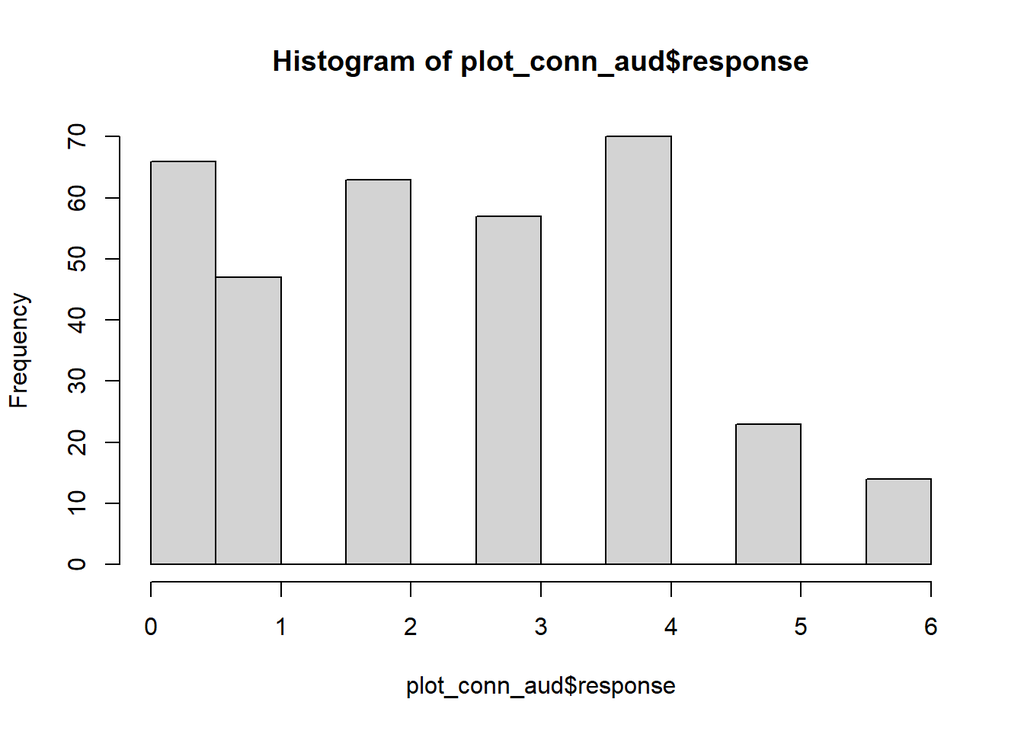

```r
hist(plot_conn_aud$response)
```

### Bayesian Multilevel Ordinal Regression

*Standardize data*

“Performs a standardization of data (z-scoring), i.e., centering and scaling, so that the data is expressed in terms of standard deviation (i.e., mean = 0, SD = 1)” “When applied to a statistical model, this function extracts the dataset, standardizes it, and refits the model with this standardized version of the dataset.”

https://easystats.github.io/datawizard/reference/standardize.html

```r
std_sc_data<-standardize(data_indchar)
```

Get prior

```r
get_prior(bf(response.f ~
                  piece + question + group + question:group + # concert chars
                  # relational chars
                  fan + fan:question +  personal_relation + personal_relation:question + group_size + group_size:question +
                  # individual chars
                  EC + AIMS + mus_stat_num +
                  (1|Pt_ID)),
          data = std_sc_data)
```

```
##                 prior     class
##                (flat)         b
##                (flat)         b
##                (flat)         b
##                (flat)         b
##                (flat)         b
##                (flat)         b
##                (flat)         b
##                (flat)         b
##                (flat)         b
##                (flat)         b
##                (flat)         b
##                (flat)         b
##                (flat)         b
##                (flat)         b
##                (flat)         b
##  student_t(3, 0, 2.5) Intercept
##  student_t(3, 0, 2.5)        sd
##  student_t(3, 0, 2.5)        sd
##  student_t(3, 0, 2.5)        sd
##  student_t(3, 0, 2.5)     sigma
##                                                          coef group resp dpar
##
##                                                          AIMS
##                                                            EC
##                                                           fan
##                                                    group_size
##                                                  groupVirtual
##                                                  mus_stat_num
##                              personal_relationRelative_Friend
##                                                     pieceFolk
##                                                pieceSchnittke
##                                   questionconnected_musicians
##                               questionconnected_musicians:fan
##                        questionconnected_musicians:group_size
##                      questionconnected_musicians:groupVirtual
##  questionconnected_musicians:personal_relationRelative_Friend
##
##
##                                                               Pt_ID
```

[output cut: 8 more lines]

```
##              (vectorized)
##              (vectorized)
##              (vectorized)
##              (vectorized)
##              (vectorized)
##              (vectorized)
##              (vectorized)
##              (vectorized)
##              (vectorized)
##              (vectorized)
##                   default
##         0         default
##         0    (vectorized)
##         0    (vectorized)
##         0         default
```

Fit model on standardized data

```r
# social connection
std_sc_full_brm_priorN01<-brm(
  bf(response.f ~ # concert chars
                  piece + question + group + question:group +
                  # relational chars
                  fan + fan:question +  personal_relation + personal_relation:question + group_size + group_size:question +
                  # individual chars
                  EC + AIMS + mus_stat_num +
                  (1|Pt_ID)),
  family = cumulative("probit"),
  data = std_sc_data,
  init = "0",
  prior = set_prior("normal(0, 1)",
                    coef = c("pieceSchnittke",
                             "pieceFolk",
                             "questionconnected_musicians",
                             "groupVirtual",
                             "fan",
                             "personal_relationRelative_Friend",
                             "questionconnected_musicians:personal_relationRelative_Friend",
                             "group_size",
                             "questionconnected_musicians:group_size",
                             "EC",
                             "AIMS",
                             "mus_stat_num",
                             "questionconnected_musicians:groupVirtual",
                             "questionconnected_musicians:fan")),
  chains = 6, # does this improve ESS?
  save_pars = save_pars(all = TRUE))
# save
save(std_sc_full_brm_priorN01, file = "standardized_connectedness_brm.rda")
```

Summary

```r
summary(std_sc_full_brm_priorN01)
```

```
##  Family: cumulative
##   Links: mu = probit; disc = identity
## Formula: response.f ~ piece + question + group + question:group + fan + fan:question + personal_relation + personal_relation:question + group_size + group_size:question + EC + AIMS + mus_stat_num + (1 | Pt_ID)
##    Data: std_sc_data (Number of observations: 680)
##   Draws: 6 chains, each with iter = 2000; warmup = 1000; thin = 1;
##          total post-warmup draws = 6000
##
## Group-Level Effects:
## ~Pt_ID (Number of levels: 125)
##               Estimate Est.Error l-95% CI u-95% CI Rhat Bulk_ESS Tail_ESS
## sd(Intercept)     1.00      0.09     0.82     1.19 1.00     1586     2657
##
## Population-Level Effects:
##                                                              Estimate Est.Error
## Intercept[1]                                                    -1.36      0.16
## Intercept[2]                                                    -0.63      0.15
## Intercept[3]                                                     0.04      0.15
## Intercept[4]                                                     0.71      0.15
## Intercept[5]                                                     1.73      0.16
## Intercept[6]                                                     2.86      0.18
## pieceSchnittke                                                  -0.32      0.10
## pieceFolk                                                        0.39      0.10
## questionconnected_musicians                                      1.17      0.11
## groupVirtual                                                    -0.61      0.30
## fan                                                             -0.01      0.12
## personal_relationRelative_Friend                                 0.76      0.31
## group_size                                                       0.20      0.13
## EC                                                               0.24      0.11
## AIMS                                                             0.19      0.12
## mus_stat_num                                                     0.04      0.11
## questionconnected_musicians:groupVirtual                         1.19      0.23
## questionconnected_musicians:fan                                  0.36      0.09
## questionconnected_musicians:personal_relationRelative_Friend     0.02      0.24
## questionconnected_musicians:group_size                           0.04      0.10
##                                                              l-95% CI u-95% CI
## Intercept[1]                                                    -1.68    -1.04
## Intercept[2]                                                    -0.93    -0.34
## Intercept[3]                                                    -0.26     0.33
## Intercept[4]                                                     0.42     1.01
## Intercept[5]                                                     1.41     2.04
```

[output cut: 50 more lines]

```
## EC                                                               2518
## AIMS                                                             2767
## mus_stat_num                                                     2677
## questionconnected_musicians:groupVirtual                         4724
## questionconnected_musicians:fan                                  4615
## questionconnected_musicians:personal_relationRelative_Friend     4411
## questionconnected_musicians:group_size                           5162
##
## Family Specific Parameters:
##      Estimate Est.Error l-95% CI u-95% CI Rhat Bulk_ESS Tail_ESS
## disc     1.00      0.00     1.00     1.00   NA       NA       NA
##
## Draws were sampled using sampling(NUTS). For each parameter, Bulk_ESS
## and Tail_ESS are effective sample size measures, and Rhat is the potential
## scale reduction factor on split chains (at convergence, Rhat = 1).
```

#### Model diagnostics

Help with interpretation can be found here: https://easystats.github.io/bayestestR/reference/check_prior.html

```r
check_prior(std_sc_full_brm_priorN01, method = "gelman")
```

```
##                                                         Parameter
## 1                                                  b_Intercept[1]
## 2                                                  b_Intercept[2]
## 3                                                  b_Intercept[3]
## 4                                                  b_Intercept[4]
## 5                                                  b_Intercept[5]
## 6                                                  b_Intercept[6]
## 7                                                b_pieceSchnittke
## 8                                                     b_pieceFolk
## 9                                   b_questionconnected_musicians
## 10                                                 b_groupVirtual
## 11                                                          b_fan
## 12                             b_personal_relationRelative_Friend
## 13                                                   b_group_size
## 14                                                           b_EC
```

[output cut: 27 more lines]

```r
diagnostic_posterior(std_sc_full_brm_priorN01)
```

```
##                                                         Parameter      Rhat
## 1                                                          b_AIMS 1.0033180
## 2                                                            b_EC 1.0028248
## 3                                                           b_fan 1.0006997
## 4                                                    b_group_size 1.0030721
## 5                                                  b_groupVirtual 1.0031582
## 6                                                  b_Intercept[1] 1.0026566
## 7                                                  b_Intercept[2] 1.0027383
## 8                                                  b_Intercept[3] 1.0026910
## 9                                                  b_Intercept[4] 1.0024604
## 10                                                 b_Intercept[5] 1.0015563
## 11                                                 b_Intercept[6] 1.0011414
## 12                                                 b_mus_stat_num 1.0053806
## 13                             b_personal_relationRelative_Friend 1.0006607
## 14                                                    b_pieceFolk 1.0005849
```

[output cut: 27 more lines]

```r
# Good:  Rhat values are near 1 but not surpassing 1.1
# Good:  ESS values are all over 1000
```

#### Describe Posterior

```r
std_sc_posterior_ciHDI<-describe_posterior(
  std_sc_full_brm_priorN01,
  component = "all",
  test = c("p_direction", "p_significance", "rope"),
  centrality = "all",
  ci_method = "HDI",
  ci = .95
)
std_sc_posterior_ciHDI
```

```
## Summary of Posterior Distribution
##
## Parameter                                                    | Median |  Mean |   MAP |         95% CI |     pd |   ps |          ROPE | % in ROPE |  Rhat |     ESS
## --------------------------------------------------------------------------------------------------------------------------------------------------------------------
## Intercept[1]                                                 |  -1.36 | -1.36 | -1.36 | [-1.67, -1.03] |   100% | 1.00 | [-0.10, 0.10] |        0% | 1.003 | 2234.00
## Intercept[2]                                                 |  -0.63 | -0.63 | -0.65 | [-0.92, -0.33] |   100% | 1.00 | [-0.10, 0.10] |        0% | 1.003 | 2274.00
## Intercept[3]                                                 |   0.04 |  0.04 |  0.04 | [-0.26,  0.33] | 59.62% | 0.33 | [-0.10, 0.10] |    51.86% | 1.003 | 2319.00
## Intercept[4]                                                 |   0.71 |  0.71 |  0.71 | [ 0.44,  1.02] |   100% | 1.00 | [-0.10, 0.10] |        0% | 1.002 | 2429.00
## Intercept[5]                                                 |   1.73 |  1.73 |  1.71 | [ 1.41,  2.04] |   100% | 1.00 | [-0.10, 0.10] |        0% | 1.002 | 2638.00
## Intercept[6]                                                 |   2.85 |  2.86 |  2.86 | [ 2.51,  3.22] |   100% | 1.00 | [-0.10, 0.10] |        0% | 1.001 | 2901.00
## pieceSchnittke                                               |  -0.32 | -0.32 | -0.31 | [-0.52, -0.12] | 99.88% | 0.99 | [-0.10, 0.10] |        0% | 1.000 | 5565.00
## pieceFolk                                                    |   0.39 |  0.39 |  0.39 | [ 0.18,  0.58] | 99.98% | 1.00 | [-0.10, 0.10] |        0% | 1.001 | 5869.00
## questionconnected_musicians                                  |   1.17 |  1.17 |  1.18 | [ 0.96,  1.38] |   100% | 1.00 | [-0.10, 0.10] |        0% | 1.000 | 5074.00
## groupVirtual                                                 |  -0.61 | -0.61 | -0.61 | [-1.19,  0.01] | 97.65% | 0.95 | [-0.10, 0.10] |     2.18% | 1.003 | 1817.00
## fan                                                          |  -0.02 | -0.01 | -0.02 | [-0.26,  0.22] | 55.05% | 0.24 | [-0.10, 0.10] |    61.16% | 1.001 | 1745.00
## personal_relationRelative_Friend                             |   0.76 |  0.76 |  0.74 | [ 0.15,  1.35] | 99.18% | 0.98 | [-0.10, 0.10] |        0% | 1.001 | 2041.00
## group_size                                                   |   0.20 |  0.20 |  0.21 | [-0.06,  0.44] | 94.03% | 0.79 | [-0.10, 0.10] |    19.04% | 1.003 | 2069.00
## EC                                                           |   0.24 |  0.24 |  0.24 | [ 0.03,  0.44] | 98.72% | 0.90 | [-0.10, 0.10] |     7.60% | 1.003 | 1661.00
## AIMS                                                         |   0.19 |  0.19 |  0.21 | [-0.02,  0.43] | 95.62% | 0.79 | [-0.10, 0.10] |    19.54% | 1.003 | 1832.00
## mus_stat_num                                                 |   0.04 |  0.04 |  0.06 | [-0.18,  0.23] | 63.28% | 0.29 | [-0.10, 0.10] |    62.77% | 1.005 | 1587.00
## questionconnected_musicians:groupVirtual                     |   1.19 |  1.19 |  1.20 | [ 0.75,  1.68] |   100% | 1.00 | [-0.10, 0.10] |        0% | 1.001 | 4795.00
## questionconnected_musicians:fan                              |   0.36 |  0.36 |  0.37 | [ 0.18,  0.53] |   100% | 1.00 | [-0.10, 0.10] |        0% | 1.000 | 5941.00
## questionconnected_musicians:personal_relationRelative_Friend |   0.03 |  0.02 |  0.04 | [-0.43,  0.52] | 54.18% | 0.38 | [-0.10, 0.10] |    34.04% | 1.000 | 5607.00
## questionconnected_musicians:group_size                       |   0.04 |  0.04 |  0.04 | [-0.15,  0.25] | 63.83% | 0.27 | [-0.10, 0.10] |    67.51% | 1.000 | 5761.00
```

“However, simulation studies data suggest that using the percentage of the full posterior distribution, instead of a CI, might be more sensitive (especially do delineate highly significant effects). Thus, we recommend that the user considers using the full ROPE percentage (by setting ci = 1), which will return the portion of the entire posterior distribution in the ROPE.”

```r
percentage_in_rope <- rope(std_sc_full_brm_priorN01, ci = 1, data = std_sc_data)
```

```
## Possible multicollinearity between b_Intercept[4] and b_Intercept[2] (r = 0.85), b_Intercept[5] and b_Intercept[2] (r = 0.77), b_Intercept[5] and b_Intercept[3] (r = 0.83), b_Intercept[6] and b_Intercept[3] (r = 0.73), b_Intercept[5] and b_Intercept[4] (r = 0.89), b_Intercept[6] and b_Intercept[4…
```

```r
percentage_in_rope
```

```
## # Proportion of samples inside the ROPE [-0.10, 0.10]:
##
## Parameter                                                    | inside ROPE
## --------------------------------------------------------------------------
## Intercept[1]                                                 |      0.00 %
## Intercept[2]                                                 |      0.03 %
## Intercept[3]                                                 |     49.27 %
## Intercept[4]                                                 |      0.00 %
## Intercept[5]                                                 |      0.00 %
## Intercept[6]                                                 |      0.00 %
## pieceSchnittke                                               |      1.30 %
## pieceFolk                                                    |      0.35 %
## questionconnected_musicians                                  |      0.00 %
## groupVirtual                                                 |      3.42 %
## fan                                                          |     58.10 %
## personal_relationRelative_Friend                             |      1.38 %
## group_size                                                   |     19.68 %
## EC                                                           |      9.55 %
## AIMS                                                         |     20.73 %
## mus_stat_num                                                 |     59.63 %
## questionconnected_musicians:groupVirtual                     |      0.00 %
## questionconnected_musicians:fan                              |      0.30 %
## questionconnected_musicians:personal_relationRelative_Friend |     32.33 %
## questionconnected_musicians:group_size                       |     64.13 %
```

```r
p_in_rope<-percentage_in_rope

round(p_in_rope$ROPE_Percentage, 3)
```

```
##  [1] 0.000 0.000 0.493 0.000 0.000 0.000 0.013 0.004 0.000 0.034 0.581 0.014
## [13] 0.197 0.096 0.207 0.596 0.000 0.003 0.323 0.641
```

```r
p_in_rope%<>%mutate(outside_rope = 1- ROPE_Percentage)

# retrieve percent
library(scales)
```

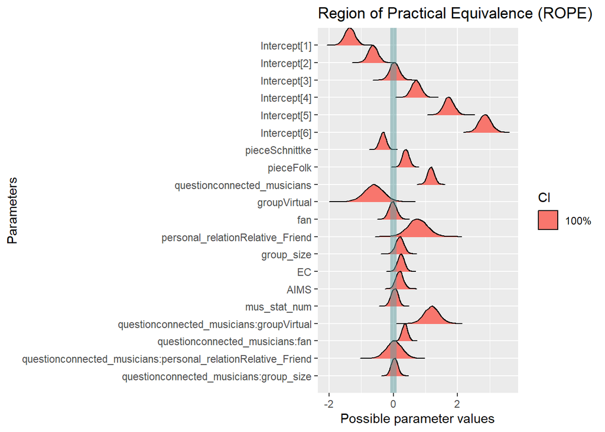

```r
p_in_rope$outside_rope_percent<-lapply(p_in_rope$outside_rope, label_percent(accuracy = 0.1))

plot(percentage_in_rope)
```

SEXIT

```r
std_sexit<-sexit(std_sc_full_brm_priorN01, significant = "default", large = "default", ci = .95) # significant default is .05 SD of outcome and .3 SD of outome
std_sexit
```

```
## # Following the Sequential Effect eXistence and sIgnificance Testing (SEXIT) framework, we report the median of the posterior distribution and its 95% CI (Highest Density Interval), along the probability of direction (pd), the probability of significance and the probability of being large. The th…
##
## - b_Intercept[1] (Median = -1.36, 95% CI [-1.68, -1.04]) has a 100.00% probability of being negative (< 0), 100.00% of being significant (< -0.05), and 100.00% of being large (< -0.30)
## - b_Intercept[2] (Median = -0.63, 95% CI [-0.93, -0.34]) has a 100.00% probability of being negative (< 0), 99.98% of being significant (< -0.05), and 98.80% of being large (< -0.30)
## - b_Intercept[3] (Median = 0.04, 95% CI [-0.26, 0.33]) has a 59.62% probability of being positive (> 0), 46.25% of being significant (> 0.05), and 4.17% of being large (> 0.30)
## - b_Intercept[4] (Median = 0.71, 95% CI [0.42, 1.01]) has a 100.00% probability of being positive (> 0), 100.00% of being significant (> 0.05), and 99.53% of being large (> 0.30)
## - b_Intercept[5] (Median = 1.73, 95% CI [1.41, 2.04]) has a 100.00% probability of being positive (> 0), 100.00% of being significant (> 0.05), and 100.00% of being large (> 0.30)
## - b_Intercept[6] (Median = 2.85, 95% CI [2.50, 3.22]) has a 100.00% probability of being positive (> 0), 100.00% of being significant (> 0.05), and 100.00% of being large (> 0.30)
## - b_pieceSchnittke (Median = -0.32, 95% CI [-0.52, -0.13]) has a 99.88% probability of being negative (< 0), 99.67% of being significant (< -0.05), and 58.12% of being large (< -0.30)
## - b_pieceFolk (Median = 0.39, 95% CI [0.19, 0.59]) has a 99.98% probability of being positive (> 0), 99.95% of being significant (> 0.05), and 80.00% of being large (> 0.30)
## - b_questionconnected_musicians (Median = 1.17, 95% CI [0.96, 1.38]) has a 100.00% probability of being positive (> 0), 100.00% of being significant (> 0.05), and 100.00% of being large (> 0.30)
## - b_groupVirtual (Median = -0.61, 95% CI [-1.22, -8.01e-03]) has a 97.65% probability of being negative (< 0), 96.62% of being significant (< -0.05), and 84.50% of being large (< -0.30)
## - b_fan (Median = -0.02, 95% CI [-0.25, 0.23]) has a 55.05% probability of being negative (< 0), 38.42% of being significant (< -0.05), and 0.80% of being large (< -0.30)
## - b_personal_relationRelative_Friend (Median = 0.76, 95% CI [0.15, 1.35]) has a 99.18% probability of being positive (> 0), 98.80% of being significant (> 0.05), and 93.40% of being large (> 0.30)
## - b_group_size (Median = 0.20, 95% CI [-0.05, 0.45]) has a 94.03% probability of being positive (> 0), 88.88% of being significant (> 0.05), and 22.02% of being large (> 0.30)
## - b_EC (Median = 0.24, 95% CI [0.03, 0.44]) has a 98.72% probability of being positive (> 0), 96.18% of being significant (> 0.05), and 28.47% of being large (> 0.30)
## - b_AIMS (Median = 0.19, 95% CI [-0.03, 0.42]) has a 95.62% probability of being positive (> 0), 89.23% of being significant (> 0.05), and 17.48% of being large (> 0.30)
## - b_mus_stat_num (Median = 0.04, 95% CI [-0.18, 0.24]) has a 63.28% probability of being positive (> 0), 46.75% of being significant (> 0.05), and 0.55% of being large (> 0.30)
## - b_questionconnected_musicians:groupVirtual (Median = 1.19, 95% CI [0.72, 1.66]) has a 100.00% probability of being positive (> 0), 100.00% of being significant (> 0.05), and 99.97% of being large (> 0.30)
## - b_questionconnected_musicians:fan (Median = 0.36, 95% CI [0.18, 0.53]) has a 100.00% probability of being positive (> 0), 99.87% of being significant (> 0.05), and 74.38% of being large (> 0.30)
## - b_questionconnected_musicians:personal_relationRelative_Friend (Median = 0.03, 95% CI [-0.46, 0.50]) has a 54.18% probability of being positive (> 0), 46.32% of being significant (> 0.05), and 12.68% of being large (> 0.30)
## - b_questionconnected_musicians:group_size (Median = 0.04, 95% CI [-0.16, 0.24]) has a 63.83% probability of being positive (> 0), 45.32% of being significant (> 0.05), and 0.48% of being large (> 0.30)
##
## Parameter                                                    | Median |             95% CI | Direction | Significance (> |0.05|) | Large (> |0.30|)
## ---------------------------------------------------------------------------------------------------------------------------------------------------
## Intercept[1]                                                 |  -1.36 |     [-1.68, -1.04] |      1.00 |                    1.00 |             1.00
## Intercept[2]                                                 |  -0.63 |     [-0.93, -0.34] |      1.00 |                    1.00 |             0.99
## Intercept[3]                                                 |   0.04 |      [-0.26, 0.33] |      0.60 |                    0.46 |             0.04
## Intercept[4]                                                 |   0.71 |       [0.42, 1.01] |      1.00 |                    1.00 |             1.00
## Intercept[5]                                                 |   1.73 |       [1.41, 2.04] |      1.00 |                    1.00 |             1.00
```

[output cut: 15 more lines]

Probability of direction

```r
pd<-p_direction(std_sc_full_brm_priorN01)
pd
```

```
## Probability of Direction
##
## Parameter                                                    |     pd
## ---------------------------------------------------------------------
## Intercept[1]                                                 |   100%
## Intercept[2]                                                 |   100%
## Intercept[3]                                                 | 59.62%
## Intercept[4]                                                 |   100%
## Intercept[5]                                                 |   100%
## Intercept[6]                                                 |   100%
## pieceSchnittke                                               | 99.88%
## pieceFolk                                                    | 99.98%
## questionconnected_musicians                                  |   100%
## groupVirtual                                                 | 97.65%
## fan                                                          | 55.05%
## personal_relationRelative_Friend                             | 99.18%
## group_size                                                   | 94.03%
## EC                                                           | 98.72%
## AIMS                                                         | 95.62%
## mus_stat_num                                                 | 63.28%
## questionconnected_musicians:groupVirtual                     |   100%
## questionconnected_musicians:fan                              |   100%
## questionconnected_musicians:personal_relationRelative_Friend | 54.18%
## questionconnected_musicians:group_size                       | 63.83%
```

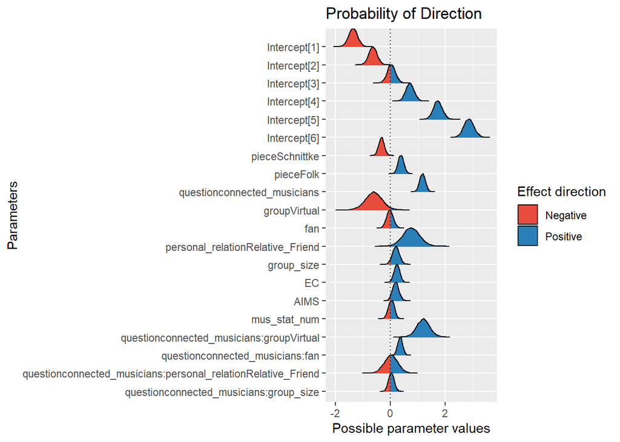

```r
plot(pd)
```

#### Estimate effects

```r
contr_piece<-estimate_contrasts(std_sc_full_brm_priorN01, contrast = "piece")
```

```
## Warning: brms' emmeans support for ordinal models is experimental and currently
## ignores the threshold parameters.

## Warning: brms' emmeans support for ordinal models is experimental and currently
## ignores the threshold parameters.
```

```r
contr_groupXquestion<-estimate_contrasts(std_sc_full_brm_priorN01, contrast = "group", at = "question")
```

```
## Warning: brms' emmeans support for ordinal models is experimental and currently
## ignores the threshold parameters.

## Warning: brms' emmeans support for ordinal models is experimental and currently
## ignores the threshold parameters.
```

```r
contr_questionXgroup<-estimate_contrasts(std_sc_full_brm_priorN01, contrast = "question", at = "group")
slope_fan<-estimate_slopes(std_sc_full_brm_priorN01, trend = "fan", at = "question")
contr_piece
```

```
## Marginal Contrasts Analysis
##
## Level1    |    Level2 | Difference |         95% CI |     pd | % in ROPE
## ------------------------------------------------------------------------
## Beethoven | Schnittke |       0.32 | [ 0.13,  0.52] | 99.88% |        0%
## Beethoven |      Folk |      -0.39 | [-0.59, -0.19] | 99.98% |        0%
## Schnittke |      Folk |      -0.71 | [-0.92, -0.49] |   100% |        0%
##
## Marginal contrasts estimated at piece
```

```r
contr_groupXquestion
```

```
## Marginal Contrasts Analysis
##
## Level1 |  Level2 |            question | Difference |        95% CI |     pd | % in ROPE
## ----------------------------------------------------------------------------------------
## Live   | Virtual |  connected_audience |       0.61 | [ 0.01, 1.22] | 97.65% |     2.18%
## Live   | Virtual | connected_musicians |      -0.59 | [-1.20, 0.01] | 97.25% |     3.35%
##
## Marginal contrasts estimated at group
```

```r
contr_questionXgroup
```

```
## Marginal Contrasts Analysis
##
## Level1             |              Level2 |   group | Difference |         95% CI |   pd | % in ROPE
## ---------------------------------------------------------------------------------------------------
## connected_audience | connected_musicians |    Live |      -1.18 | [-1.46, -0.92] | 100% |        0%
## connected_audience | connected_musicians | Virtual |      -2.37 | [-2.80, -1.93] | 100% |        0%
##
## Marginal contrasts estimated at question
```

```r
slope_fan
```

```
## Estimated Marginal Effects
##
## question            | Coefficient |        95% CI |     pd
## ----------------------------------------------------------
## connected_audience  |       -0.02 | [-0.25, 0.23] | 55.05%
## connected_musicians |        0.34 | [ 0.10, 0.59] | 99.75%
## Marginal effects estimated for fan
```

#### Visualize

```r
SC_params<-parameters(std_sc_full_brm_priorN01)
SC_params
```

```
## Parameter                                                    | Median |         95% CI |     pd |  Rhat |     ESS
## -----------------------------------------------------------------------------------------------------------------
## Intercept[1]                                                 |  -1.36 | [-1.68, -1.04] |   100% | 1.003 | 2234.00
## Intercept[2]                                                 |  -0.63 | [-0.93, -0.34] |   100% | 1.003 | 2274.00
## Intercept[3]                                                 |   0.04 | [-0.26,  0.33] | 59.62% | 1.003 | 2319.00
## Intercept[4]                                                 |   0.71 | [ 0.42,  1.01] |   100% | 1.002 | 2429.00
## Intercept[5]                                                 |   1.73 | [ 1.41,  2.04] |   100% | 1.002 | 2638.00
## Intercept[6]                                                 |   2.85 | [ 2.50,  3.22] |   100% | 1.001 | 2901.00
## pieceSchnittke                                               |  -0.32 | [-0.52, -0.13] | 99.88% | 1.000 | 5565.00
## pieceFolk                                                    |   0.39 | [ 0.19,  0.59] | 99.98% | 1.001 | 5869.00
## questionconnected_musicians                                  |   1.17 | [ 0.96,  1.38] |   100% | 1.000 | 5074.00
## groupVirtual                                                 |  -0.61 | [-1.22, -0.01] | 97.65% | 1.003 | 1817.00
## fan                                                          |  -0.02 | [-0.25,  0.23] | 55.05% | 1.001 | 1745.00
## personal_relationRelative_Friend                             |   0.76 | [ 0.15,  1.35] | 99.18% | 1.001 | 2041.00
## group_size                                                   |   0.20 | [-0.05,  0.45] | 94.03% | 1.003 | 2069.00
## EC                                                           |   0.24 | [ 0.03,  0.44] | 98.72% | 1.003 | 1661.00
## AIMS                                                         |   0.19 | [-0.03,  0.42] | 95.62% | 1.003 | 1832.00
## mus_stat_num                                                 |   0.04 | [-0.18,  0.24] | 63.28% | 1.005 | 1587.00
## questionconnected_musicians:groupVirtual                     |   1.19 | [ 0.72,  1.66] |   100% | 1.001 | 4795.00
## questionconnected_musicians:fan                              |   0.36 | [ 0.18,  0.53] |   100% | 1.000 | 5941.00
## questionconnected_musicians:personal_relationRelative_Friend |   0.03 | [-0.46,  0.50] | 54.18% | 1.000 | 5607.00
## questionconnected_musicians:group_size                       |   0.04 | [-0.16,  0.24] | 63.83% | 1.000 | 5761.00
```

```
##
## Uncertainty intervals (equal-tailed) and p-values (two-tailed) computed
##   using a MCMC distribution approximation.
```

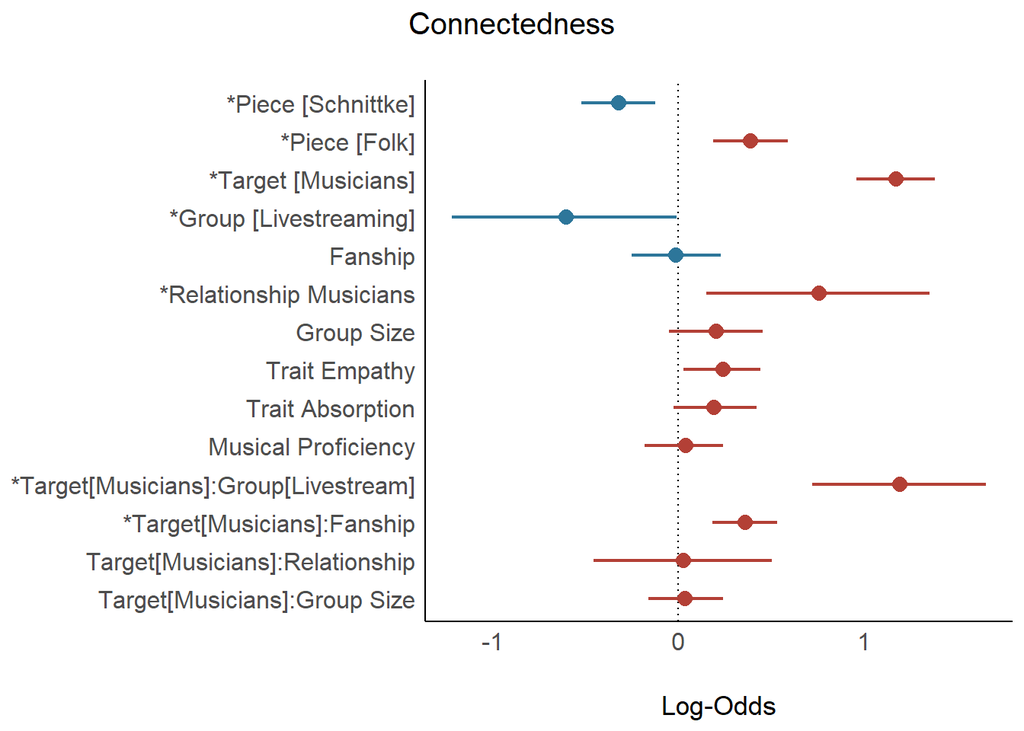

```r
labels = c( "Target[Musicians]:Group Size", "Target[Musicians]:Relationship", "*Target[Musicians]:Fanship", "*Target[Musicians]:Group[Livestream]", "Musical Proficiency",  "Trait Absorption","Trait Empathy","Group Size","*Relationship Musicians", "Fanship","*Group [Livestreaming]", "*Target [Musicians]","*Piece [Folk]",  "*Piece [Schnittke]")

colours_DSQ<-c("#2d769a","#b34036")

#SC_param_plot<-
plot(SC_params) +
  scale_y_discrete(labels = labels)+
  scale_color_manual(values = rev(colours_DSQ))+
  labs(title = "Connectedness")+
  theme(plot.title = element_text(hjust = 0.5))
```

```r
graphname<-paste0("../plots/dot_whisker_sc.jpg")

ggsave(graphname, width = 15, height = 10, units = 'cm', dpi = 500)
```